# Ethereum Regime Detection and Forecasting Model

I develop a regime-aware forecasting system for Ethereum by combining AR(3)-GJR-GARCH return forecasting with a 3-state Markov regime model for risk filtering and position sizing in this notebook.

1. Data preparation
2. EDA and regime justification
3. Fitting and evaluation of baseline forecast models and baseline volatility model
4. Regime model, walk-forward backtest, and parameter tuning
5. Locked live forecast, combined recommendation, and projection charts
6. Comparison with other baseline models

## 1) Imports, Data load and return construction

```python
import yfinance as yf
import pandas as pd
import statsmodels.api as sm
import matplotlib.pyplot as plt
import numpy as np
import seaborn as sns
import itertools
import json
import time

from arch import arch_model
from scipy import stats
from pathlib import Path
from dataclasses import dataclass
from typing import Tuple, Dict, List, Optional

from statsmodels.graphics.tsaplots import plot_acf
from statsmodels.tsa.stattools import adfuller, kpss
from statsmodels.stats.diagnostic import het_arch
from statsmodels.tsa.arima.model import ARIMA
from statsmodels.tsa.holtwinters import ExponentialSmoothing
```

```python
eth = yf.download("ETH-USD", start="2015-08-01", interval="1d")
```

```
[*********************100%***********************]  1 of 1 completed
```

```python
eth["log_return"] = np.log(eth["Close"]).diff()
eth = eth.dropna()

returns = eth["log_return"]
```

## 2. Exploratory Data Analysis and Regime Justification

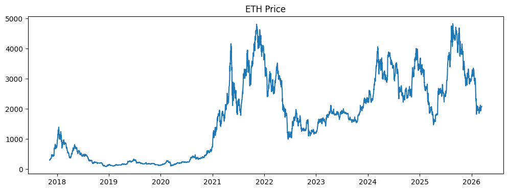

```python
plt.figure(figsize=(12,4))
plt.plot(eth.index, eth["Close"])
plt.title("ETH Price")
plt.show()
```

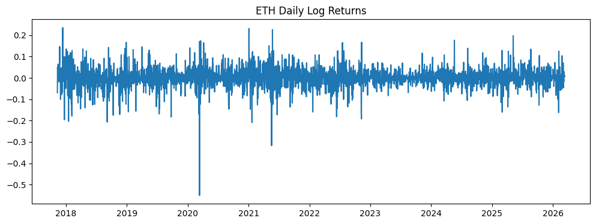

```python
plt.figure(figsize=(12,4))
plt.plot(returns)
plt.title("ETH Daily Log Returns")
plt.show()
```

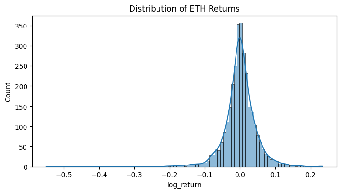

```python
plt.figure(figsize=(8,4))
sns.histplot(returns, bins=100, kde=True)
plt.title("Distribution of ETH Returns")
plt.show()
```

```python
print("Mean:", returns.mean())
print("Std:", returns.std())
print("Skew:", stats.skew(returns))
print("Kurtosis:", stats.kurtosis(returns))
```

```
Mean: 0.0006144674805950575
Std: 0.045391484641305074
Skew: -0.7740529399432362
Kurtosis: 10.507297975290918
```

```python
jb_stat, jb_p = stats.jarque_bera(returns)
print("Jarque-Bera p-value:", jb_p)
```

```
Jarque-Bera p-value: 0.0
```

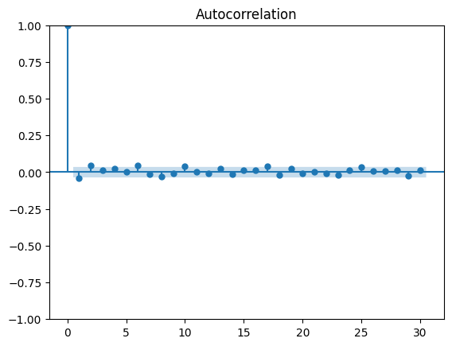

```python
from statsmodels.graphics.tsaplots import plot_acf

plot_acf(returns, lags=30)
plt.show()
```

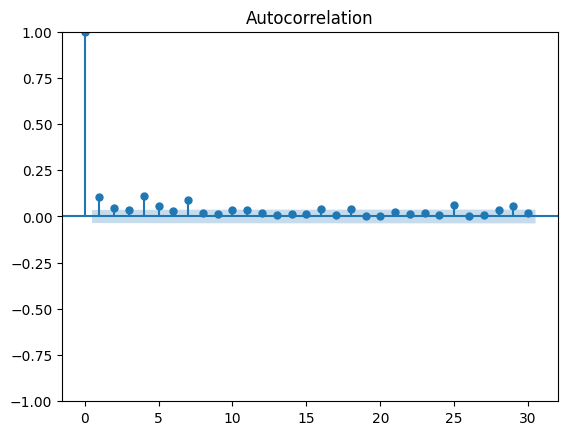

```python
plot_acf(returns**2, lags=30)
plt.show()
```

**Data Insights and Observations**

The ETH price series shows multiple large boom-and-bust cycles between 2017 and 2026. Periods such as the 2021 rally and subsequent corrections highlight the highly volatile nature of cryptocurrency markets. The price process itself is clearly non-stationary, which motivates modeling returns rather than price levels.

The daily log return series fluctuates around zero with frequent large spikes in both directions, indicating high volatility and occasional extreme shocks. Large negative and positive movements appear intermittently, suggesting volatility clustering, where periods of calm are followed by bursts of large movements.

The distribution of returns is strongly non-normal. While centered near zero, the histogram shows heavy tails and asymmetry. Summary statistics confirm this behavior: the returns exhibit negative skewness (-0.77) and very high kurtosis (~10.5), indicating a higher probability of extreme outcomes than a normal distribution. The Jarque–Bera test strongly rejects normality (p ≈ 0), confirming that Gaussian assumptions are inappropriate for modeling the return distribution even squaring.

The autocorrelation function (ACF) of returns shows very little serial correlation, with most lags close to zero and within confidence bounds. This suggests that returns behave approximately like a weakly dependent or near-white-noise process, meaning simple linear predictability in returns is limited.

However, the ACF of squared returns shows noticeable positive autocorrelation at several lags, indicating persistent volatility clustering. This pattern is a well-known stylized fact in financial time series and motivates the use of conditional volatility models such as GARCH.

Overall, the EDA reveals several key facts of ethereum returns:

1. Price levels are non-stationary, but returns are approximately stationary.
2. Returns exhibit fat tails and skewness, deviating strongly from normality.
3. Linear autocorrelation in returns is weak.
4. Volatility clustering is present, as shown by autocorrelation in squared returns.

These characteristics justify the modeling choices I use later in the analysis, including AR processes for returns, GARCH-type models for volatility, and regime-switching models to capture different volatility environments.

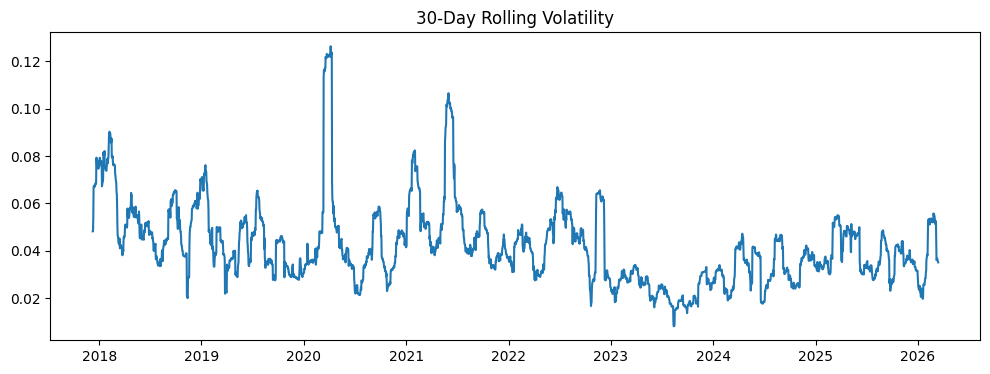

```python
eth["rolling_vol"] = returns.rolling(30).std()

plt.figure(figsize=(12,4))
plt.plot(eth["rolling_vol"])
plt.title("30-Day Rolling Volatility")
plt.show()
```

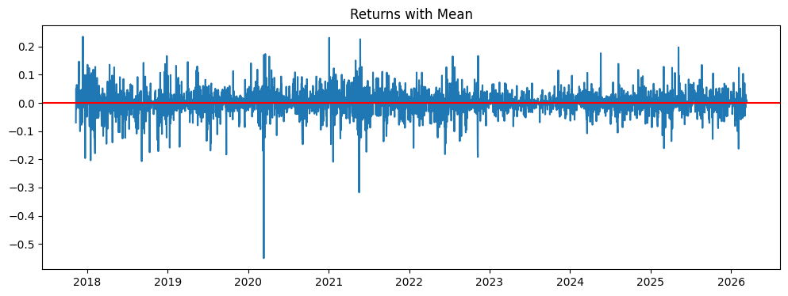

```python
plt.figure(figsize=(12,4))
plt.plot(returns)
plt.axhline(returns.mean(), color="red")
plt.title("Returns with Mean")
plt.show()
```

```python
from statsmodels.tsa.stattools import adfuller, kpss

# ADF
adf_stat, adf_p, *_ = adfuller(returns)
print("ADF p-value:", adf_p)

# KPSS (null = stationary)
kpss_stat, kpss_p, *_ = kpss(returns, regression='c')
print("KPSS p-value:", kpss_p)
```

```
ADF p-value: 1.5913204800758255e-29
KPSS p-value: 0.1
```

```python
from statsmodels.stats.diagnostic import het_arch

arch_stat, arch_p, _, _ = het_arch(returns)
print("ARCH test p-value:", arch_p)
```

```
ARCH test p-value: 4.898978971700958e-16
```

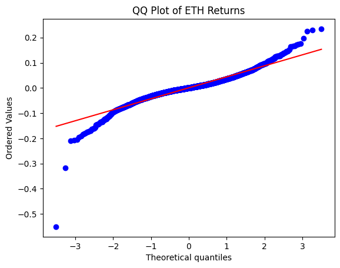

```python
stats.probplot(returns, dist="norm", plot=plt)
plt.title("QQ Plot of ETH Returns")
plt.show()
```

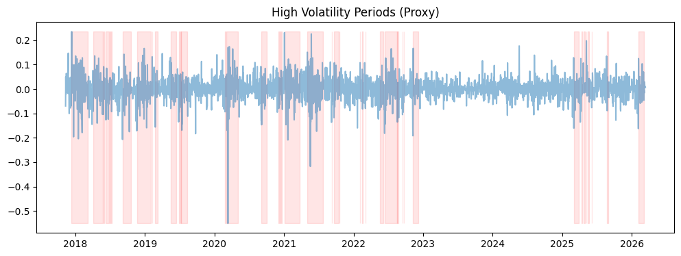

```python
vol = returns.rolling(30).std()

high_vol = vol > vol.quantile(0.7)

plt.figure(figsize=(12,4))
plt.plot(returns, alpha=0.5)
plt.fill_between(returns.index, returns.min(), returns.max(),
                 where=high_vol, color='red', alpha=0.1)
plt.title("High Volatility Periods (Proxy)")
plt.show()
```

**Additional Diagnostics and Volatility Analysis**

The 30-day rolling volatility plot also highlights clear volatility clustering in Ethereum returns. Volatility varies substantially across time, with pronounced spikes during periods of market stress such as the 2020 crash and the 2021 market cycle. These clusters confirm that volatility is time-varying rather than constant, which motivates the use of conditional volatility models such as GARCH.

The return series with its mean overlaid shows that daily log returns fluctuate around a value close to zero. While the mean is small, the series exhibits frequent large positive and negative shocks, reinforcing the presence of heavy-tailed behavior and substantial market risk.

Formal stationarity tests support modeling the return series rather than prices. The Augmented Dickey-Fuller test strongly rejects the presence of a unit root (p-value ≈ 0), while the KPSS test fails to reject stationarity. Together, these results indicate that ETH log returns are stationary, making them appropriate for time-series modeling.

The ARCH test produces an extremely small p-value, strongly rejecting the null hypothesis of homoskedasticity. This confirms the presence of conditional heteroskedasticity, meaning volatility changes over time and depends on past shocks. This result provides statistical justification for using GARCH-type volatility models.

The QQ plot further illustrates the non-normal nature of returns. The tails deviate substantially from the theoretical mean line, indicating fat tails and extreme observations. This suggests that large shocks occur more frequently than predicted by a Gaussian distribution, which is a common fact in financial markets in general.

Finally, the highlighted high-volatility periods identify time intervals where realized volatility exceeds the 70th percentile of its historical distribution. These periods correspond to clusters of large return movements, visually reinforcing the presence of volatility regimes and motivating the later use of regime-switching and volatility-targeting models.

Overall, these diagnostics confirm several key facts that can help to model Ethereum returns:

1. Returns are stationary but highly volatile
2. Volatility is time-varying and clustered
3. Return distributions exhibit fat tails and extreme events
4. Significant conditional heteroskedasticity is present

These characteristics justify the modeling approach adopted later, including AR dynamics for returns, GARCH-type models for volatility clustering, and regime-switching models for different market environments.

## 3. Regime-Model EDA

```python
#2-Regime Markov Model

model_2 = sm.tsa.MarkovRegression(
    returns,
    k_regimes=2,
    trend="c",
    switching_variance=True
)

res_2 = model_2.fit(method="bfgs", maxiter=8000, disp=False)

print("Converged:", res_2.mle_retvals.get("converged", None))
print(res_2.summary())
```

```
Converged: True
                        Markov Switching Model Results
==============================================================================
Dep. Variable:             log_return   No. Observations:                 3046
Model:               MarkovRegression   Log Likelihood                5470.034
Date:                Fri, 13 Mar 2026   AIC                         -10928.069
Time:                        19:58:36   BIC                         -10891.939
Sample:                             0   HQIC                        -10915.083
                               - 3046
Covariance Type:               approx
                             Regime 0 parameters
==============================================================================
                 coef    std err          z      P>|z|      [0.025      0.975]
------------------------------------------------------------------------------
const          0.0015      0.001      2.185      0.029       0.000       0.003
sigma2         0.0007   4.61e-05     14.319      0.000       0.001       0.001
                             Regime 1 parameters
==============================================================================
                 coef    std err          z      P>|z|      [0.025      0.975]
------------------------------------------------------------------------------
const         -0.0012      0.002     -0.504      0.614      -0.006       0.004
sigma2         0.0051      0.000     14.002      0.000       0.004       0.006
                         Regime transition parameters
==============================================================================
                 coef    std err          z      P>|z|      [0.025      0.975]
------------------------------------------------------------------------------
p[0->0]        0.9052      0.017     54.497      0.000       0.873       0.938
p[1->0]        0.2058      0.035      5.928      0.000       0.138       0.274
==============================================================================

Warnings:
[1] Covariance matrix calculated using numerical (complex-step) differentiation.
```

```python
# Identify high-vol regime (auto-detect via variance)

probs_2 = res_2.smoothed_marginal_probabilities

sigma2_0 = float(res_2.params["sigma2[0]"])
sigma2_1 = float(res_2.params["sigma2[1]"])

high_vol_regime = 0 if sigma2_0 > sigma2_1 else 1

print("High-vol regime:", high_vol_regime)
print("Variance regime 0:", sigma2_0)
print("Variance regime 1:", sigma2_1)
```

```
High-vol regime: 1
Variance regime 0: 0.0006606493865143176
Variance regime 1: 0.005095952430811245
```

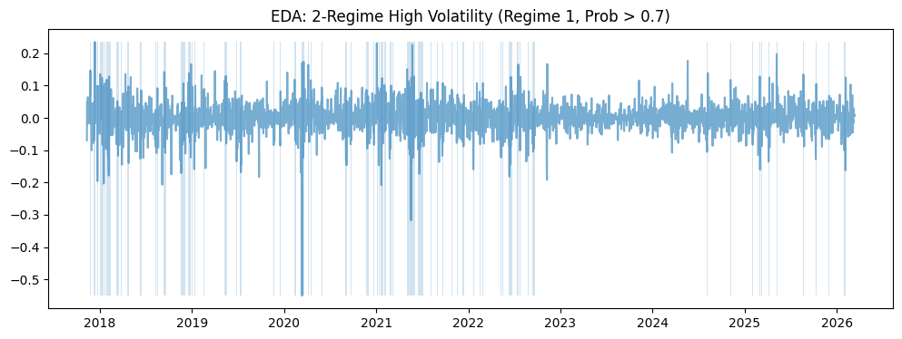

```python
# Plot high-vol regime periods

high_prob = probs_2[high_vol_regime] > 0.7

plt.figure(figsize=(12, 4))
plt.plot(returns, alpha=0.6)

plt.fill_between(
    returns.index,
    returns.min(),
    returns.max(),
    where=high_prob,
    alpha=0.2
)

plt.title(
    f"EDA: 2-Regime High Volatility (Regime {high_vol_regime}, Prob > 0.7)"
)
plt.show()
```

**Insights from fitting a 2-regime Markov Model**

The two-regime Markov switching model separates Ethereum returns into two volatility states: a low-volatility “normal market” regime and a high-volatility “turbulent market” regime. The estimated variances show that the high-volatility regime has significantly larger return dispersion, confirming that Ethereum experiences periods of intense market stress.

The transition probabilities indicate strong regime persistence, meaning the market tends to remain in the same state for extended periods. Most of the time Ethereum stays in the stable regime, while the high-volatility regime appears intermittently during market shocks, visible in the highlighted regions of the plot.

While the model successfully captures the presence of volatility clustering and crisis periods, it simplifies market behavior into only two states. Cryptocurrency markets often move through intermediate conditions such as recovery phases, moderate volatility periods, or speculative rallies, which cannot be fully represented with only a binary regime structure.

Therefore, the next step extends the framework to a 3-regime Markov switching model, which allows the system to capture low-volatility, medium-volatility, and crisis regimes, providing a more realistic representation of crypto market dynamics.

```python
#3-Regime Markov Model

returns_eda = returns.dropna().astype(float).sort_index()
if not isinstance(returns_eda.index, pd.DatetimeIndex):
    returns_eda.index = pd.to_datetime(returns_eda.index)
returns_eda = returns_eda.asfreq("D").dropna()

model_3 = sm.tsa.MarkovRegression(
    returns_eda,
    k_regimes=3,
    trend="c",
    switching_variance=True
)

res_3 = model_3.fit(method="bfgs", maxiter=12000, disp=False)

print("Converged:", res_3.mle_retvals.get("converged", None))
print("AIC:", res_3.aic, "BIC:", res_3.bic)
print(res_3.summary())
```

```
Converged: True
AIC: -11029.894342914055 BIC: -10957.635328512593
                        Markov Switching Model Results
==============================================================================
Dep. Variable:             log_return   No. Observations:                 3046
Model:               MarkovRegression   Log Likelihood                5526.947
Date:                Fri, 13 Mar 2026   AIC                         -11029.894
Time:                        19:58:40   BIC                         -10957.635
Sample:                             0   HQIC                        -11003.923
                               - 3046
Covariance Type:               approx
                             Regime 0 parameters
==============================================================================
                 coef    std err          z      P>|z|      [0.025      0.975]
------------------------------------------------------------------------------
const         -0.0011      0.001     -1.299      0.194      -0.003       0.001
sigma2         0.0002   3.61e-05      4.511      0.000    9.22e-05       0.000
                             Regime 1 parameters
==============================================================================
                 coef    std err          z      P>|z|      [0.025      0.975]
------------------------------------------------------------------------------
const          0.0032      0.001      2.955      0.003       0.001       0.005
sigma2         0.0013      0.000      9.279      0.000       0.001       0.002
                             Regime 2 parameters
==============================================================================
                 coef    std err          z      P>|z|      [0.025      0.975]
------------------------------------------------------------------------------
const         -0.0048      0.004     -1.291      0.197      -0.012       0.002
sigma2         0.0064      0.001      9.245      0.000       0.005       0.008
                         Regime transition parameters
==============================================================================
                 coef    std err          z      P>|z|      [0.025      0.975]
------------------------------------------------------------------------------
p[0->0]        0.6648      0.070      9.494      0.000       0.528       0.802
p[1->0]        0.1366      0.040      3.448      0.001       0.059       0.214
p[2->0]     2.243e-09        nan        nan        nan         nan         nan
p[0->1]        0.2761      0.062      4.442      0.000       0.154       0.398
p[1->1]        0.8321      0.034     24.121      0.000       0.764       0.900
p[2->1]        0.1590      0.041      3.893      0.000       0.079       0.239
==============================================================================

Warnings:
[1] Covariance matrix calculated using numerical (complex-step) differentiation.
```

```python
#Identify regimes by volatility (sigma)

sigma2 = np.array([float(res_3.params[f"sigma2[{i}]"]) for i in range(3)])
sigma = np.sqrt(sigma2)

order = np.argsort(sigma)  # low -> high
low_regime = int(order[0])
mid_regime = int(order[1])
high_regime = int(order[2])

print("Regime sigmas:", np.round(sigma, 6))
print("Low vol regime:", low_regime)
print("Mid vol regime:", mid_regime)
print("High vol regime:", high_regime)
```

```
Regime sigmas: [0.012766 0.036111 0.079968]
Low vol regime: 0
Mid vol regime: 1
High vol regime: 2
```

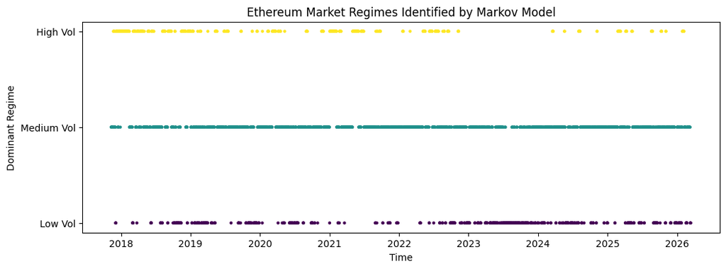

```python
regime_state = res_3.smoothed_marginal_probabilities.idxmax(axis=1)

plt.figure(figsize=(12,4))
plt.scatter(regime_state.index, regime_state, c=regime_state, cmap="viridis", s=5)
plt.title("Ethereum Market Regimes Identified by Markov Model")
plt.yticks([0,1,2], ["Low Vol", "Medium Vol", "High Vol"])
plt.xlabel("Time")
plt.ylabel("Dominant Regime")
plt.show()
```

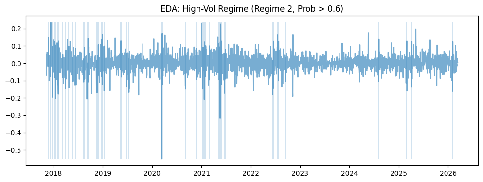

```python
#Highlight high-vol regime on returns

# Convert probabilities to dataframe aligned with returns
probs_df = pd.DataFrame(
    res_3.smoothed_marginal_probabilities,
    index=returns_eda.index
)

# identify high volatility regime
high_prob = probs_df[high_regime] > 0.6

plt.figure(figsize=(12,4))

plt.plot(returns_eda, alpha=0.6)

plt.fill_between(
    returns_eda.index,
    returns_eda.min(),
    returns_eda.max(),
    where=high_prob.values,
    alpha=0.2
)

plt.title(f"EDA: High-Vol Regime (Regime {high_regime}, Prob > 0.6)")
plt.show()
```

**Insights from fitting a 3-regime Markov Model**

The three-regime model identifies distinct volatility states in Ethereum’s daily returns between 2017 and 2026. The model produced stronger fit statistics (AIC −11029, BIC −10957) compared to the two regime model, indicating that allowing returns to switch between 3 different regimes explains the data better than a binary regime model.

The model identifies three market regimes. Regime 0 (Low Volatility) shows small, statistically insignificant returns (~−0.10% daily) with low variance, representing sideways or calm markets. Regime 1 (Medium Volatility) has a positive and statistically significant mean return (~+0.32% daily) with moderate volatility, indicating the typical bullish environment where most market growth occurs. Regime 2 (High Volatility) exhibits extremely large variance and a negative average return (~−0.48%), corresponding to crisis periods such as major sell-offs or liquidation events.

Overall, the regime model reveals that Ethereum markets alternate between three states , namely, calm, growth, and crisis states. Therefore, I chose this model as one of the 3 time series models which comprises my trading architecture.

## 4. Baseline 30-Day Forecast Models

This section fits simpler benchmark models on the same ETH return series so they can be compared fairly against the final combined model.

Models included:

- AR(1)
- ARIMA(2,0,2)
- Holt-Winters exponential smoothing

```python
# 1) Clean series for modeling

price_series = eth["Close"]
if isinstance(price_series, pd.DataFrame):
    price_series = price_series.iloc[:, 0]

price_series = price_series.dropna().astype(float).sort_index()
if not isinstance(price_series.index, pd.DatetimeIndex):
    price_series.index = pd.to_datetime(price_series.index)

price_series = price_series.asfreq("D").ffill()

returns_series = returns.copy()
if isinstance(returns_series, pd.DataFrame):
    returns_series = returns_series.iloc[:, 0]

returns_series = pd.Series(returns_series).dropna().astype(float).sort_index()
returns_series = returns_series.asfreq("D").dropna()
returns_series.name = "log_return"

returns_pct = returns_series * 100.0

horizon = 30
capital = 10_000.0
target_vol_simple = 0.02

min_return_buffer_simple = 0.001
momentum_60d_simple = float(returns_series.rolling(60).sum().iloc[-1])

def common_strategy_layer(expected_return: float, vol: float, momentum: float):
    vol = float(vol)

    if np.isnan(vol) or vol <= 0:
        return "CASH", 0.0

    position = min(1.0, target_vol_simple / vol)

    if expected_return <= 0:
        stance = "CASH / BEARISH"
        position = 0.0

    elif expected_return <= min_return_buffer_simple:
        stance = "BUY / HOLD SMALL"
        position *= 0.30

    elif momentum <= 0:
        stance = "CASH / WAIT FOR CONFIRMATION"
        position = 0.0

    elif position >= 0.75:
        stance = "BUY / HOLD LARGE"

    elif position >= 0.30:
        stance = "BUY / HOLD MODERATE"

    else:
        stance = "BUY / HOLD SMALL"

    return stance, float(position)

# 2) Helpers

def daily_log_to_30d_simple(daily_log_return: float, horizon: int = 30) -> float:
    return float(np.exp(daily_log_return * horizon) - 1.0)

def safe_position_from_vol(vol: float, target: float = 0.02) -> float:
    vol = float(vol)
    if np.isnan(vol) or vol <= 0:
        return 0.0
    return float(min(1.0, target / vol))


def build_model_output(model_name: str, exp_30d_return: float, daily_vol: float, momentum: float):
    stance, pos = common_strategy_layer(exp_30d_return, daily_vol, momentum)

    eth_alloc = capital * pos
    cash_alloc = capital - eth_alloc

    return {
        "Model": model_name,
        "Expected 30D Return %": round(exp_30d_return * 100, 3),
        "Daily Volatility %": round(daily_vol * 100, 3),
        "Recommended Position %": round(pos * 100, 1),
        "ETH Allocation": round(eth_alloc, 2),
        "Cash Allocation": round(cash_alloc, 2),
        "Stance": stance,
    }
```

```python
# 3) AR(1)

ar1_model = ARIMA(returns_series, order=(1, 0, 0))
ar1_res = ar1_model.fit()

ar1_daily_forecast = float(ar1_res.forecast(steps=1).iloc[0])
ar1_30d_return = daily_log_to_30d_simple(ar1_daily_forecast, horizon=horizon)
ar1_daily_vol = float(returns_series.std())

ar1_output = build_model_output("AR(1)", ar1_30d_return, ar1_daily_vol, momentum_60d_simple)

print("\n=== AR(1) MODEL ===")
for k, v in ar1_output.items():
    if k != "Model":
        print(f"{k}: {v}")
```

```
=== AR(1) MODEL ===
Expected 30D Return %: 1.207
Daily Volatility %: 4.539
Recommended Position %: 0.0
ETH Allocation: 0.0
Cash Allocation: 10000.0
Stance: CASH / WAIT FOR CONFIRMATION
```

```python
# 4) ARIMA(2,0,2)

arima_model = ARIMA(returns_series, order=(2, 0, 2))
arima_res = arima_model.fit()

arima_daily_forecast = float(arima_res.forecast(steps=1).iloc[0])
arima_30d_return = daily_log_to_30d_simple(arima_daily_forecast, horizon=horizon)
arima_daily_vol = float(returns_series.std())

arima_output = build_model_output("ARIMA(2,0,2)", arima_30d_return, arima_daily_vol, momentum_60d_simple)

print("\n=== ARIMA(2,0,2) MODEL ===")
for k, v in arima_output.items():
    if k != "Model":
        print(f"{k}: {v}")
```

```
=== ARIMA(2,0,2) MODEL ===
Expected 30D Return %: -3.796
Daily Volatility %: 4.539
Recommended Position %: 0.0
ETH Allocation: 0.0
Cash Allocation: 10000.0
Stance: CASH / BEARISH
```

```python
# -----------------------------
# 6) Holt-Winters
# -----------------------------
hw_model = ExponentialSmoothing(
    returns_series,
    trend="add",
    seasonal=None
)
hw_res = hw_model.fit()

hw_daily_forecast = float(hw_res.forecast(1).iloc[0])
hw_30d_return = daily_log_to_30d_simple(hw_daily_forecast, horizon=horizon)
hw_daily_vol = float(returns_series.std())

hw_output = build_model_output("Holt-Winters", hw_30d_return, hw_daily_vol, momentum_60d_simple)

print("\n=== HOLT-WINTERS MODEL ===")
for k, v in hw_output.items():
    if k != "Model":
        print(f"{k}: {v}")
```

```
=== HOLT-WINTERS MODEL ===
Expected 30D Return %: 0.359
Daily Volatility %: 4.539
Recommended Position %: 0.0
ETH Allocation: 0.0
Cash Allocation: 10000.0
Stance: CASH / WAIT FOR CONFIRMATION
```

```python
baseline_outputs = [ar1_output, arima_output, hw_output]
baseline_comparison_df = pd.DataFrame(baseline_outputs)

print("\n=== BASELINE MODEL COMPARISON ===")
display(baseline_comparison_df)
```

```
=== BASELINE MODEL COMPARISON ===
```

|  | Model | Expected 30D Return % | Daily Volatility % | Recommended Position % | ETH Allocation | Cash Allocation | Stance |
| --- | --- | --- | --- | --- | --- | --- | --- |
| 0 | AR(1) | 1.207 | 4.539 | 0.0 | 0.0 | 10000.0 | CASH / WAIT FOR CONFIRMATION |
| 1 | ARIMA(2,0,2) | -3.796 | 4.539 | 0.0 | 0.0 | 10000.0 | CASH / BEARISH |
| 2 | Holt-Winters | 0.359 | 4.539 | 0.0 | 0.0 | 10000.0 | CASH / WAIT FOR CONFIRMATION |

```
=== BASELINE MODELS RANKED BY EXPECTED 30D RETURN ===
```

|  | Model | Expected 30D Return % | Daily Volatility % | Recommended Position % | ETH Allocation | Cash Allocation | Stance |
| --- | --- | --- | --- | --- | --- | --- | --- |
| 0 | AR(1) | 1.207 | 4.539 | 0.0 | 0.0 | 10000.0 | CASH / WAIT FOR CONFIRMATION |
| 1 | Holt-Winters | 0.359 | 4.539 | 0.0 | 0.0 | 10000.0 | CASH / WAIT FOR CONFIRMATION |
| 2 | ARIMA(2,0,2) | -3.796 | 4.539 | 0.0 | 0.0 | 10000.0 | CASH / BEARISH |

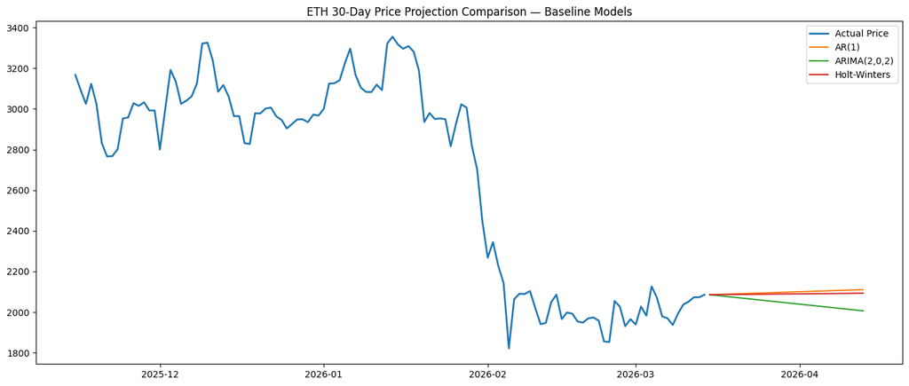

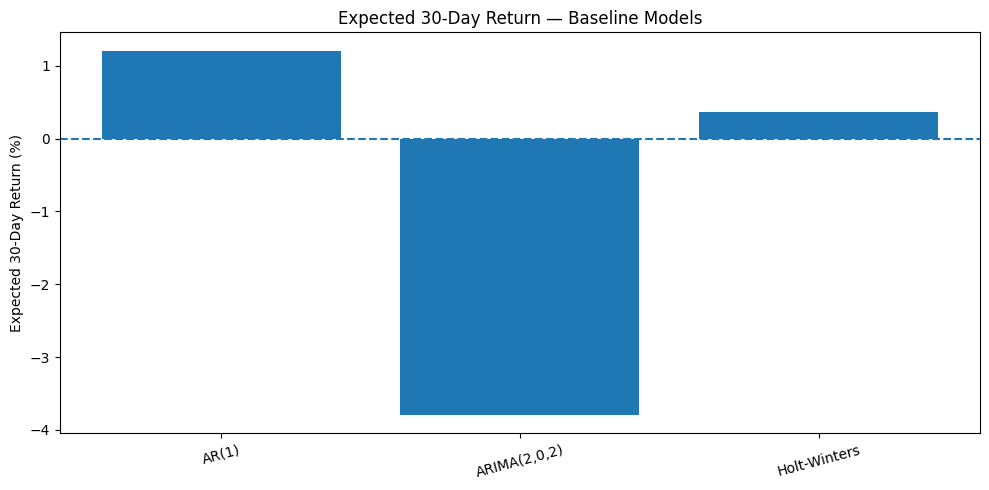

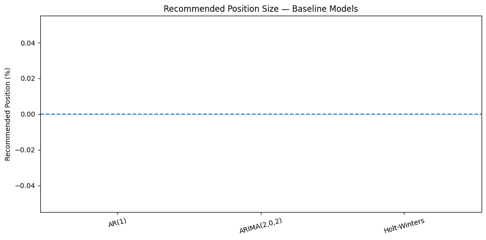

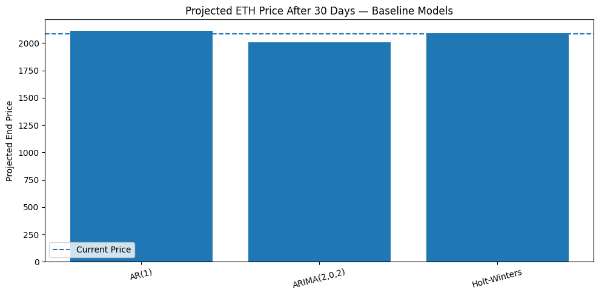

```
Current ETH price: 2085.47
```

|  | Model | Projected 30D End Price |
| --- | --- | --- |
| 0 | AR(1) | 2110.647775 |
| 1 | ARIMA(2,0,2) | 2006.300597 |
| 2 | Holt-Winters | 2092.951789 |

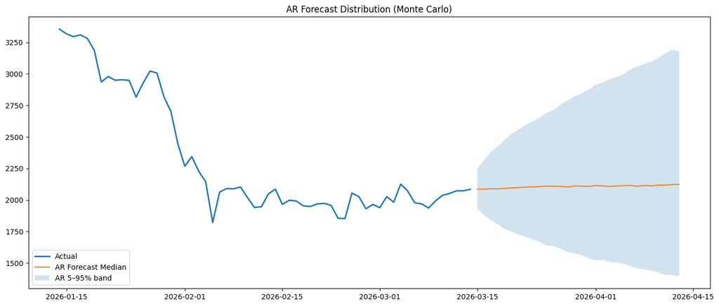

```
=== BASELINE SUMMARY ===
Current price: 2085.47
Best baseline by return: AR(1)
Best baseline expected 30D return: 1.207%
Highest recommended position: AR(1)
```

```python
# 1) End-price projections

last_price = float(price_series.iloc[-1])
future_dates = pd.date_range(
    price_series.index[-1] + pd.Timedelta(days=1),
    periods=horizon,
    freq="D"
)

ar1_end_price = last_price * (1 + ar1_30d_return)
arima_end_price = last_price * (1 + arima_30d_return)
hw_end_price = last_price * (1 + hw_30d_return)

ar1_path = np.linspace(last_price, ar1_end_price, horizon)
arima_path = np.linspace(last_price, arima_end_price, horizon)
hw_path = np.linspace(last_price, hw_end_price, horizon)

# 2) Return ranked table

baseline_table = baseline_comparison_df.copy()

baseline_table = baseline_table[
    [
        "Model",
        "Expected 30D Return %",
        "Daily Volatility %",
        "Recommended Position %",
        "ETH Allocation",
        "Cash Allocation",
        "Stance"
    ]
]

baseline_ranked = baseline_table.sort_values(
    "Expected 30D Return %",
    ascending=False
).reset_index(drop=True)

print("\n=== BASELINE MODELS RANKED BY EXPECTED 30D RETURN ===")
display(baseline_ranked)

# 3) Price projection comparison chart

plt.figure(figsize=(14, 6))
plt.plot(price_series.index[-120:], price_series.iloc[-120:], label="Actual Price", linewidth=2)
plt.plot(future_dates, ar1_path, label="AR(1)")
plt.plot(future_dates, arima_path, label="ARIMA(2,0,2)")
plt.plot(future_dates, hw_path, label="Holt-Winters")

plt.title("ETH 30-Day Price Projection Comparison — Baseline Models")
plt.legend()
plt.tight_layout()
plt.show()

# 4) Return comparison bar chart

plt.figure(figsize=(10, 5))
plt.bar(
    baseline_table["Model"],
    baseline_table["Expected 30D Return %"]
)
plt.axhline(0, linestyle="--")
plt.ylabel("Expected 30-Day Return (%)")
plt.title("Expected 30-Day Return — Baseline Models")
plt.xticks(rotation=15)
plt.tight_layout()
plt.show()

# 5) Position comparison bar chart

plt.figure(figsize=(10, 5))
plt.bar(
    baseline_table["Model"],
    baseline_table["Recommended Position %"]
)
plt.axhline(0, linestyle="--")
plt.ylabel("Recommended Position (%)")
plt.title("Recommended Position Size — Baseline Models")
plt.xticks(rotation=15)
plt.tight_layout()
plt.show()

# 6) End-price comparison bar chart

baseline_end_prices = pd.DataFrame({
    "Model": ["AR(1)", "ARIMA(2,0,2)", "Holt-Winters"],
    "Projected 30D End Price": [
        ar1_end_price,
        arima_end_price,
        hw_end_price
    ]
})

plt.figure(figsize=(10, 5))
plt.bar(
    baseline_end_prices["Model"],
    baseline_end_prices["Projected 30D End Price"]
)
plt.axhline(last_price, linestyle="--", label="Current Price")
plt.ylabel("Projected End Price")
plt.title("Projected ETH Price After 30 Days — Baseline Models")
plt.legend()
plt.xticks(rotation=15)
plt.tight_layout()
plt.show()

print("\nCurrent ETH price:", round(last_price, 2))
display(baseline_end_prices)

# 7) AR Monte Carlo fan chart

np.random.seed(42)

n_sim = 5000
sim_paths = []

for _ in range(n_sim):
    sim_rets = np.random.normal(ar1_daily_forecast, ar1_daily_vol, horizon)
    sim_price_path = last_price * np.exp(np.cumsum(sim_rets))
    sim_paths.append(sim_price_path)

sim_paths = np.array(sim_paths)

ar_median = np.median(sim_paths, axis=0)
ar_p05 = np.quantile(sim_paths, 0.05, axis=0)
ar_p95 = np.quantile(sim_paths, 0.95, axis=0)

plt.figure(figsize=(14, 6))
plt.plot(price_series.index[-60:], price_series.iloc[-60:], label="Actual", linewidth=2)
plt.plot(future_dates, ar_median, label="AR Forecast Median")
plt.fill_between(future_dates, ar_p05, ar_p95, alpha=0.20, label="AR 5–95% band")
plt.title("AR Forecast Distribution (Monte Carlo)")
plt.legend()
plt.tight_layout()
plt.show()

# 8) Summary print block

print("\n=== BASELINE SUMMARY ===")
print(f"Current price: {last_price:.2f}")
print(f"Best baseline by return: {baseline_ranked.iloc[0]['Model']}")
print(f"Best baseline expected 30D return: {baseline_ranked.iloc[0]['Expected 30D Return %']:.3f}%")
print(f"Highest recommended position: {baseline_table.sort_values('Recommended Position %', ascending=False).iloc[0]['Model']}")
```

**Insights from model comparison amongst baseline models**

This reinforces the conclusion that the baseline models alone provide weak predictive signals, motivating the need for more sophisticated approaches such as regime-switching and volatility-aware models to better capture cryptocurrency market dynamics.

## 5. Volatility Model Baseline

Before constructing the combined model, a GJR GARCH specification is fit to confirm that ETH returns exhibit persistent conditional volatility and to provide a simple volatility benchmark.

```python
# GJR GARCH fit on percent returns
returns_pct = returns * 100

garch = arch_model(
    returns_pct,
    vol="GARCH",
    p=1,
    q=1,
    o=1,
    dist="t"
)

garch_fit = garch.fit(disp="off")
print(garch_fit.summary())
```

```
                      Constant Mean - GJR-GARCH Model Results
====================================================================================
Dep. Variable:                   log_return   R-squared:                       0.000
Mean Model:                   Constant Mean   Adj. R-squared:                  0.000
Vol Model:                        GJR-GARCH   Log-Likelihood:               -8466.42
Distribution:      Standardized Student's t   AIC:                           16944.8
Method:                  Maximum Likelihood   BIC:                           16981.0
                                              No. Observations:                 3046
Date:                      Fri, Mar 13 2026   Df Residuals:                     3045
Time:                              19:58:42   Df Model:                            1
                                 Mean Model
===========================================================================
                 coef    std err          t      P>|t|     95.0% Conf. Int.
---------------------------------------------------------------------------
mu             0.0784  5.406e-02      1.450      0.147 [-2.757e-02,  0.184]
                              Volatility Model
===========================================================================
                 coef    std err          t      P>|t|     95.0% Conf. Int.
---------------------------------------------------------------------------
omega          0.7161      0.542      1.321      0.186    [ -0.346,  1.779]
alpha[1]       0.1136  3.255e-02      3.490  4.824e-04  [4.982e-02,  0.177]
gamma[1]       0.0231  4.071e-02      0.568      0.570 [-5.666e-02,  0.103]
beta[1]        0.8718  5.331e-02     16.353  4.167e-60    [  0.767,  0.976]
                              Distribution
========================================================================
                 coef    std err          t      P>|t|  95.0% Conf. Int.
------------------------------------------------------------------------
nu             3.1895      0.202     15.803  2.984e-56 [  2.794,  3.585]
========================================================================

Covariance estimator: robust
```

```python
garch_forecast = garch_fit.forecast(horizon=30)
vol_forecast = np.sqrt(garch_forecast.variance.values[-1])

print("Next 30-day GARCH volatility forecast:")
print(vol_forecast)
```

```
Next 30-day GARCH volatility forecast:
[3.70616842 3.79603414 3.88355621 3.96889048 4.05217593 4.13353716
 4.2130864  4.29092514 4.36714556 4.44183165 4.51506024 4.58690181
 4.6574212  4.72667822 4.79472822 4.8616225  4.92740874 4.99213136
 5.05583179 5.11854878 5.18031863 5.24117539 5.30115106 5.36027578
 5.41857793 5.47608434 5.53282033 5.5888099  5.64407577 5.69863951]
```

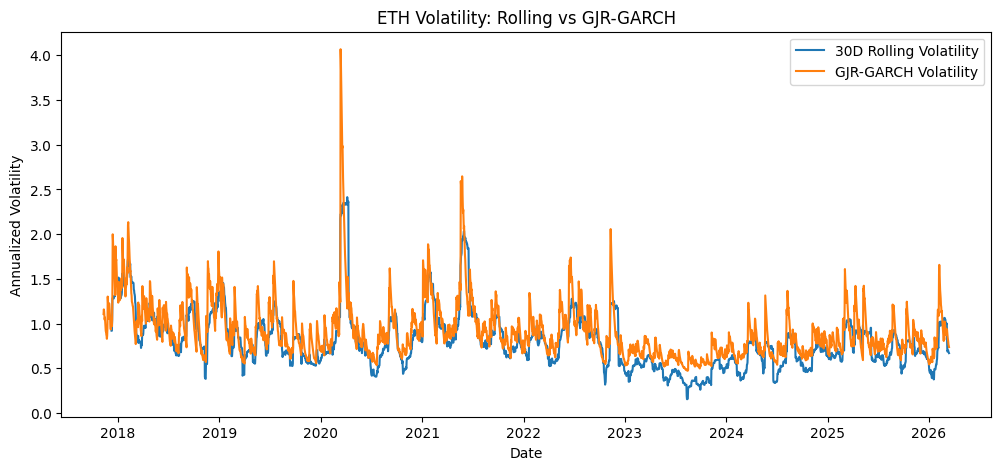

```python
# Rolling volatility
rolling_vol = returns_series.rolling(30).std() * np.sqrt(365)

# GJR-GARCH conditional volatility
garch_vol = garch_fit.conditional_volatility / 100
garch_vol = garch_vol * np.sqrt(365)

plt.figure(figsize=(12,5))

plt.plot(rolling_vol, label="30D Rolling Volatility")
plt.plot(garch_vol, label="GJR-GARCH Volatility")

plt.title("ETH Volatility: Rolling vs GJR-GARCH")
plt.ylabel("Annualized Volatility")
plt.xlabel("Date")
plt.legend()

plt.savefig("volatility_comparison.png", dpi=300, bbox_inches="tight")

plt.show()
```

**Insights from Volatility Model Baseline**

To better capture volatility dynamics in Ethereum returns, a GJR-GARCH model was estimated and compared with simple rolling volatility. The results show strong volatility persistence, with a high β coefficient (0.872) indicating that shocks to volatility decay slowly over time. The α parameter (0.113) is statistically significant, confirming that recent return shocks immediately increase volatility. The model also assumes a Student-t distribution (ν ≈ 3.19), capturing the heavy tails commonly observed in Ethereum returns as demonstrated above.

The volatility plot shows that the GJR-GARCH estimate closely tracks the 30-day rolling volatility but reacts more sharply to sudden market shocks, particularly during extreme events such as the spikes around 2020 and 2021. This confirms the presence of volatility clustering, where periods of high volatility tend to persist.

The 30-day GARCH forecast indicates rising volatility, increasing from roughly 3.7% to about 5.7% daily volatility over the forecast horizon, suggesting an elevated risk environment. However, while GARCH models capture time-varying volatility well, they still assume a single underlying market structure. Cryptocurrency markets frequently alternate between calm, growth, and crisis periods, meaning volatility dynamics can change structurally. This observation motivates the use of the 3 regime-switching model, which allows returns and volatility to evolve under different hidden market states and better capture these structural shifts.

## 6. Walk-Forward Strategy Engine and Parameter Search

This section contains:

- robust Markov fitting
- regime-specific position building
- walk-forward backtesting
- parameter search and best-parameter selection
- locked model creation for live forecasting

```python
# Defining the data class for the walk forward engine as well as helper functions

@dataclass
class WFParams:
    # walk-forward structure
    train_days: int = 365 * 3
    test_days: int = 30
    step_days: int = 30
    buffer_days: int = 120

    # regime model
    k_regimes: int = 3

    # strategy knobs
    short_mom_window: int = 20
    long_mom_window: int = 60
    crisis_cut: float = 0.20
    vol_lookback: int = 20
    target_vol: float = 0.02

    base_low: float = 1.0
    base_mid: float = 0.6

    regime_vol_weight: float = 0.5
    realized_vol_weight: float = 0.5

    min_return_buffer: float = 0.0
    confirm_days: int = 3           # NEW

    # risk & costs
    initial_capital: float = 10_000.0
    dd_limit: float = 0.20
    returns_are_log: bool = True
    tcost_bp: float = 0.0
    stop_remainder_of_window: bool = True


def ensure_daily(x: pd.Series) -> pd.Series:
    x = x.dropna().astype(float).sort_index()
    if not isinstance(x.index, pd.DatetimeIndex):
        x.index = pd.to_datetime(x.index)
    return x.asfreq("D").dropna()


def to_simple_returns(r: pd.Series, returns_are_log: bool) -> pd.Series:
    return np.expm1(r) if returns_are_log else r


def fit_markov_robust(train: pd.Series, k_regimes: int = 3):
    mod = sm.tsa.MarkovRegression(
        train,
        k_regimes=k_regimes,
        trend="c",
        switching_variance=True
    )

    best_res = None
    best_method = None

    for method in ["bfgs", "powell"]:
        try:
            res = mod.fit(method=method, maxiter=8000, disp=False)
            if best_res is None or res.llf > best_res.llf:
                best_res = res
                best_method = method
            if res.mle_retvals.get("converged", False):
                return res, method
        except Exception:
            continue

    if best_res is None:
        raise RuntimeError("Markov model failed for all fit methods.")

    return best_res, f"{best_method}_nonconverged"


def pick_crisis_regime_by_weighted_var(train: pd.Series, probs_train: pd.DataFrame) -> int:
    x = train.values.astype(float)
    cols = list(probs_train.columns)

    vars_ = []
    for j in cols:
        w = probs_train[j].values.astype(float)
        wsum = w.sum()
        if wsum <= 1e-12:
            vars_.append(-np.inf)
            continue
        mu = (w * x).sum() / wsum
        var = (w * (x - mu) ** 2).sum() / wsum
        vars_.append(var)

    return int(cols[int(np.argmax(vars_))])


def rolling_confirm(signal: pd.Series, confirm_days: int = 3) -> pd.Series:
    return (signal.astype(int).rolling(confirm_days).sum() == confirm_days)
```

```python
# Defining the position function

def build_positions_regime_specific(
    seg: pd.Series,
    probs_filt_seg: pd.DataFrame,
    crisis_regime: int,
    low_regime: int,
    mid_regime: int,
    short_mom_window: int = 20,
    long_mom_window: int = 60,
    crisis_cut: float = 0.20,
    vol_lookback: int = 20,
    target_vol: float = 0.02,
    base_low: float = 1.0,
    base_mid: float = 0.6,
    regime_sigma_map: Dict[int, float] = None,
    regime_vol_weight: float = 0.5,
    realized_vol_weight: float = 0.5,
    min_return_buffer: float = 0.0,
    confirm_days: int = 3
) -> pd.Series:
    """
    Soft regime-specific strategy:
    - low-vol regime contributes if long trend > min_return_buffer
    - mid-vol regime contributes if short and long trend > min_return_buffer
    - crisis regime reduces exposure smoothly
    - position scaled by combined volatility
    - confirmation filter reduces rapid switching
    """

    short_trend = seg.rolling(short_mom_window).sum()
    long_trend = seg.rolling(long_mom_window).sum()

    p_low = probs_filt_seg[low_regime]
    p_mid = probs_filt_seg[mid_regime]
    p_crisis = probs_filt_seg[crisis_regime]

    sig_low_raw = (long_trend > min_return_buffer)
    sig_mid_raw = ((short_trend > min_return_buffer) & (long_trend > min_return_buffer))
    sig_crisis_raw = (p_crisis > crisis_cut)

    sig_low = rolling_confirm(sig_low_raw, confirm_days=confirm_days).astype(float)
    sig_mid = rolling_confirm(sig_mid_raw, confirm_days=confirm_days).astype(float)
    sig_crisis = rolling_confirm(sig_crisis_raw, confirm_days=confirm_days).astype(float)

    base = (
        base_low * p_low * sig_low
        + base_mid * p_mid * sig_mid
    )

    crisis_penalty = (1.0 - (p_crisis / max(crisis_cut, 1e-8))).clip(lower=0.0, upper=1.0)
    crisis_penalty = np.where(sig_crisis > 0, crisis_penalty, 1.0)
    crisis_penalty = pd.Series(crisis_penalty, index=seg.index)
    base = base * crisis_penalty

    realized_vol = seg.rolling(vol_lookback).std()

    if regime_sigma_map is None:
        regime_vol = realized_vol.copy()
    else:
        regime_vol = pd.Series(0.0, index=seg.index)
        for reg, sig in regime_sigma_map.items():
            if reg in probs_filt_seg.columns:
                regime_vol += probs_filt_seg[reg] * sig

    combined_vol = (
        realized_vol_weight * realized_vol +
        regime_vol_weight * regime_vol
    )

    scale = (target_vol / combined_vol).replace([np.inf, -np.inf], np.nan).fillna(0.0)
    scale = scale.clip(upper=1.0)

    pos = (base * scale).fillna(0.0)
    return pos.clip(lower=0.0, upper=1.0)
```

```python
# Defining the backtesting function

def backtest_stop_next_day_cash(
    returns_win: pd.Series,
    pos_win: pd.Series,
    initial_capital: float,
    dd_limit: float,
    returns_are_log: bool,
    tcost_bp: float,
    stop_remainder_of_window: bool
) -> Dict:

    if len(returns_win) < 2:
        raise ValueError("Need at least 2 rows in window.")

    base_ret = to_simple_returns(returns_win, returns_are_log)
    pos_eff = pos_win.astype(float).copy()

    equity = pd.Series(index=returns_win.index, dtype=float)
    equity.iloc[0] = float(initial_capital)

    peak = equity.iloc[0]
    stopped = False
    stop_trigger_index = None

    for t in range(1, len(returns_win)):
        turnover = abs(float(pos_eff.iloc[t]) - float(pos_eff.iloc[t - 1]))
        cost = (tcost_bp / 10_000.0) * turnover

        pnl_ret = float(pos_eff.iloc[t - 1]) * float(base_ret.iloc[t])
        equity.iloc[t] = equity.iloc[t - 1] * (1.0 + pnl_ret - cost)

        peak = max(peak, equity.iloc[t])
        dd = (peak - equity.iloc[t]) / peak

        if (not stopped) and (dd > dd_limit):
            stopped = True
            stop_trigger_index = t
            if t + 1 < len(pos_eff):
                if stop_remainder_of_window:
                    pos_eff.iloc[t + 1:] = 0.0
                else:
                    pos_eff.iloc[t + 1] = 0.0

    total_ret = equity.iloc[-1] / equity.iloc[0] - 1.0
    dd_series = (equity.cummax() - equity) / equity.cummax()
    max_dd = float(dd_series.max())
    trades = int((pos_eff.diff().fillna(0) != 0).sum())

    return {
        "total_return": float(total_ret),
        "max_dd": float(max_dd),
        "stopped": bool(stopped),
        "stop_trigger_index": stop_trigger_index,
        "trades": trades,
        "equity": equity,
        "pos_eff": pos_eff
    }
```

```python
# Defining the walk forward engine function

def walk_forward_regime_strategy(
    returns: pd.Series,
    params: WFParams,
    debug_first_window: bool = True
) -> Tuple[pd.DataFrame, List[pd.Series]]:

    returns = ensure_daily(returns)

    results: List[dict] = []
    equities: List[pd.Series] = []

    start_idx = params.train_days + params.buffer_days

    for start in range(start_idx, len(returns) - params.test_days, params.step_days):
        train_end = start
        test_end = start + params.test_days

        train = returns.iloc[train_end - params.train_days : train_end]
        seg   = returns.iloc[train_end - params.buffer_days : test_end]
        win   = returns.iloc[train_end : test_end]

        res_train, fit_method = fit_markov_robust(train, k_regimes=params.k_regimes)
        converged = bool(res_train.mle_retvals.get("converged", False))

        probs_train = res_train.filtered_marginal_probabilities
        crisis_regime = pick_crisis_regime_by_weighted_var(train, probs_train)

        mod_seg = sm.tsa.MarkovRegression(
            seg,
            k_regimes=params.k_regimes,
            trend="c",
            switching_variance=True
        )
        res_seg = mod_seg.filter(res_train.params)
        probs_filt_seg = res_seg.filtered_marginal_probabilities

        param_names = list(res_train.params.index)
        vals = np.asarray(res_train.params, dtype=float)

        regime_sigma_map = {}
        for i in range(params.k_regimes):
            sigma_name = f"sigma2[{i}]"
            if sigma_name in param_names:
                regime_sigma_map[i] = float(np.sqrt(vals[param_names.index(sigma_name)]))

        if len(regime_sigma_map) < params.k_regimes:
            weighted_var = {}
            for r in probs_train.columns:
                w = probs_train[r].astype(float).values
                x = train.astype(float).values
                w_sum = w.sum()
                if w_sum > 0:
                    mu_r = np.sum(w * x) / w_sum
                    var_r = np.sum(w * (x - mu_r) ** 2) / w_sum
                    weighted_var[int(r)] = float(var_r)
                else:
                    weighted_var[int(r)] = np.inf

            ordered_regs = sorted(weighted_var, key=weighted_var.get)

            for r, v in weighted_var.items():
                if r not in regime_sigma_map:
                    regime_sigma_map[r] = float(np.sqrt(v)) if np.isfinite(v) else np.nan
        else:
            ordered_regs = sorted(regime_sigma_map, key=regime_sigma_map.get)

        if len(ordered_regs) < params.k_regimes:
            ordered_regs = list(range(params.k_regimes))

        other_regs = [r for r in range(params.k_regimes) if r != crisis_regime]
        other_regs = sorted(other_regs, key=lambda r: regime_sigma_map.get(r, np.inf))

        if len(other_regs) < 2:
            continue

        low_regime = other_regs[0]
        mid_regime = other_regs[1]
        high_regime = crisis_regime

        pos_seg = build_positions_regime_specific(
            seg=seg,
            probs_filt_seg=probs_filt_seg,
            crisis_regime=high_regime,
            low_regime=low_regime,
            mid_regime=mid_regime,
            short_mom_window=params.short_mom_window,
            long_mom_window=params.long_mom_window,
            crisis_cut=params.crisis_cut,
            vol_lookback=params.vol_lookback,
            target_vol=params.target_vol,
            base_low=params.base_low,
            base_mid=params.base_mid,
            regime_sigma_map=regime_sigma_map,
            regime_vol_weight=params.regime_vol_weight,
            realized_vol_weight=params.realized_vol_weight,
            min_return_buffer=params.min_return_buffer,
            confirm_days=params.confirm_days
        )

        pos_win = pos_seg.loc[win.index]

        long_days = int((pos_win > 0).sum())
        cash_days = int((pos_win == 0).sum())

        if debug_first_window and len(results) == 0:
            crisis_p_seg = probs_filt_seg[high_regime]
            short_trend_seg = seg.rolling(params.short_mom_window).sum()
            long_trend_seg = seg.rolling(params.long_mom_window).sum()
            realized_vol_seg = seg.rolling(params.vol_lookback).std()

            regime_vol_seg = pd.Series(0.0, index=seg.index)
            for reg, sig in regime_sigma_map.items():
                if reg in probs_filt_seg.columns:
                    regime_vol_seg += probs_filt_seg[reg] * sig

            combined_vol_seg = (
                params.realized_vol_weight * realized_vol_seg
                + params.regime_vol_weight * regime_vol_seg
            )

            print("DEBUG FIRST WINDOW:")
            print("picked crisis_regime:", crisis_regime)
            print("short trend > 0 rate (seg):", float((short_trend_seg > 0).mean()))
            print("long trend > 0 rate (seg):", float((long_trend_seg > 0).mean()))
            print("crisis_p mean (seg):", float(crisis_p_seg.mean()))
            print("crisis_p <= crisis_cut rate (seg):", float((crisis_p_seg <= params.crisis_cut).mean()))
            print("realized_vol mean (seg):", float(realized_vol_seg.mean()))
            print("regime_vol mean (seg):", float(regime_vol_seg.mean()))
            print("combined_vol mean (seg):", float(combined_vol_seg.mean()))
            print("pos long/cash (test pre-stop):", long_days, cash_days)

        bt = backtest_stop_next_day_cash(
            returns_win=win,
            pos_win=pos_win,
            initial_capital=params.initial_capital,
            dd_limit=params.dd_limit,
            returns_are_log=params.returns_are_log,
            tcost_bp=params.tcost_bp,
            stop_remainder_of_window=params.stop_remainder_of_window
        )

        pos_eff = bt["pos_eff"]

        results.append({
            "start": win.index[0],
            "end": win.index[-1],
            "return_%": bt["total_return"] * 100,
            "max_dd_%": bt["max_dd"] * 100,
            "stopped": bt["stopped"],
            "stop_trigger_index": bt["stop_trigger_index"],
            "trades": bt["trades"],
            "converged": converged,
            "fit_method": fit_method,
            "llf_train": float(res_train.llf),
            "aic_train": float(res_train.aic),
            "bic_train": float(res_train.bic),
            "crisis_regime": crisis_regime,
            "long_days": long_days,
            "cash_days": cash_days,
            "long_days_eff": int((pos_eff > 0).sum()),
            "cash_days_eff": int((pos_eff == 0).sum()),
        })

        equities.append(bt["equity"])

    return pd.DataFrame(results), equities
```

```python
# Function to display summary stats from walkforward backtest
def summarize_wf(wf_df: pd.DataFrame) -> Dict[str, float]:
    return {
        "windows": int(len(wf_df)),
        "conv_%": float(wf_df["converged"].mean() * 100),
        "pos_months_%": float((wf_df["return_%"] > 0).mean() * 100),
        "mean_%": float(wf_df["return_%"].mean()),
        "median_%": float(wf_df["return_%"].median()),
        "worst_%": float(wf_df["return_%"].min()),
        "best_%": float(wf_df["return_%"].max()),
        "dd_stop_%": float(wf_df["stopped"].mean() * 100),
        "avg_trades": float(wf_df["trades"].mean()),
        "avg_long_days": float(wf_df["long_days"].mean()),
        "avg_cash_days": float(wf_df["cash_days"].mean()),
    }
```

## 7. Baseline Walk-Forward Backtest

```python
# First walkforward with untuned hyperparameters

params = WFParams(
    k_regimes=3,
    crisis_cut=0.20,
    vol_lookback=20,
    target_vol=0.02,
    short_mom_window=20,
    long_mom_window=60,
    base_low=1.0,
    base_mid=0.6,
    regime_vol_weight=0.5,
    realized_vol_weight=0.5,
    min_return_buffer=0.0,
    confirm_days=3,
    dd_limit=0.20,
    initial_capital=10_000,
    returns_are_log=True,
    tcost_bp=0.0,
    stop_remainder_of_window=True
)

wf_df, wf_equities = walk_forward_regime_strategy(
    returns=returns,
    params=params,
    debug_first_window=True
)

print(summarize_wf(wf_df))
```

```
DEBUG FIRST WINDOW:
picked crisis_regime: 2
short trend > 0 rate (seg): 0.72
long trend > 0 rate (seg): 0.6066666666666667
crisis_p mean (seg): 0.14276047271859688
crisis_p <= crisis_cut rate (seg): 0.84
realized_vol mean (seg): 0.05498743562718991
regime_vol mean (seg): 0.04691753548901173
combined_vol mean (seg): 0.05136203659215311
pos long/cash (test pre-stop): 30 0
```

[output not shown]

[output cut: 181 more lines]

[output not shown]

```
{'windows': 61, 'conv_%': 100.0, 'pos_months_%': 29.508196721311474, 'mean_%': 0.9575694289415851, 'median_%': 0.0, 'worst_%': -10.631525999546609, 'best_%': 19.90685011036777, 'dd_stop_%': 0.0, 'avg_trades': 14.721311475409836, 'avg_long_days': 14.62295081967213, 'avg_cash_days': 15.37704918032787}
```

**Baseline Walk-Forward Interpretation**

The initial walk-forward test of the 3-regime Markov switching strategy, using untuned parameters, was run across 61 test windows and achieved 100% model convergence, showing that the estimation procedure was stable throughout. The strategy generated positive returns in 29.5% of windows, with an average return of 0.96% per window and a median return of 0%, indicating that performance was uneven and driven by a limited number of stronger winning periods.

The return profile was highly dispersed, with a best window of +19.9% and a worst window of −10.6%, which is consistent with the highly variable nature of Ethereum returns. On average, the strategy made 14.7 trades per window and spent about 14.6 days long and 15.4 days in cash, suggesting fairly active switching between invested and defensive states.

Overall, this untuned baseline shows that the regime-switching framework is operationally stable and capable of capturing some upside, but its raw performance is still inconsistent. This makes it a useful starting benchmark before hyperparameter tuning, where the goal is to improve signal quality, increase the share of profitable windows, and achieve a better balance between upside capture and downside control.

## 8. Parameter Grid Search

```python
def grid_search_reuse_markov(
    returns: pd.Series,
    base_params: WFParams,
    grid: dict
) -> pd.DataFrame:

    returns = ensure_daily(returns)

    combos = list(itertools.product(
        grid["short_mom_window"],
        grid["long_mom_window"],
        grid["crisis_cut"],
        grid["base_mid"],
        grid["dd_limit"],
        grid["target_vol"],
        grid["regime_vol_weight"],
        grid["min_return_buffer"],
        grid["confirm_days"],
    ))

    rows = []
    start_idx = base_params.train_days + base_params.buffer_days

    for start in range(start_idx, len(returns) - base_params.test_days, base_params.step_days):
        train_end = start
        test_end = start + base_params.test_days

        train = returns.iloc[train_end - base_params.train_days: train_end]
        seg   = returns.iloc[train_end - base_params.buffer_days: test_end]
        win   = returns.iloc[train_end: test_end]

        res_train, fit_method = fit_markov_robust(train, k_regimes=base_params.k_regimes)
        converged = bool(res_train.mle_retvals.get("converged", False))

        mod_seg = sm.tsa.MarkovRegression(
            seg,
            k_regimes=base_params.k_regimes,
            trend="c",
            switching_variance=True
        )
        res_seg = mod_seg.filter(res_train.params)
        probs_filt_seg = res_seg.filtered_marginal_probabilities

        probs_train = res_train.filtered_marginal_probabilities
        crisis_regime = pick_crisis_regime_by_weighted_var(train, probs_train)

        param_names = list(res_train.params.index)
        vals = np.asarray(res_train.params, dtype=float)

        regime_sigma_map = {}
        for i in range(base_params.k_regimes):
            sigma_name = f"sigma2[{i}]"
            if sigma_name in param_names:
                regime_sigma_map[i] = float(np.sqrt(vals[param_names.index(sigma_name)]))

        if len(regime_sigma_map) < base_params.k_regimes:
            weighted_var = {}
            for r in probs_train.columns:
                w = probs_train[r].astype(float).values
                x = train.astype(float).values
                w_sum = w.sum()
                if w_sum > 0:
                    mu_r = np.sum(w * x) / w_sum
                    var_r = np.sum(w * (x - mu_r) ** 2) / w_sum
                    weighted_var[int(r)] = float(var_r)
                else:
                    weighted_var[int(r)] = np.inf

            for r, v in weighted_var.items():
                if r not in regime_sigma_map:
                    regime_sigma_map[r] = float(np.sqrt(v)) if np.isfinite(v) else np.nan

        other_regs = [r for r in range(base_params.k_regimes) if r != crisis_regime]
        other_regs = sorted(other_regs, key=lambda r: regime_sigma_map.get(r, np.inf))

        if len(other_regs) < 2:
            continue

        low_regime = other_regs[0]
        mid_regime = other_regs[1]
        high_regime = crisis_regime

        for (
            short_mom_window,
            long_mom_window,
            crisis_cut,
            base_mid,
            dd_limit,
            target_vol,
            regime_vol_weight,
            min_return_buffer,
            confirm_days
        ) in combos:

            if short_mom_window >= long_mom_window:
                continue

            realized_vol_weight = 1.0 - float(regime_vol_weight)

            pos_seg = build_positions_regime_specific(
                seg=seg,
                probs_filt_seg=probs_filt_seg,
                crisis_regime=high_regime,
                low_regime=low_regime,
                mid_regime=mid_regime,
                short_mom_window=int(short_mom_window),
                long_mom_window=int(long_mom_window),
                crisis_cut=float(crisis_cut),
                vol_lookback=base_params.vol_lookback,
                target_vol=float(target_vol),
                base_low=base_params.base_low,
                base_mid=float(base_mid),
                regime_sigma_map=regime_sigma_map,
                regime_vol_weight=float(regime_vol_weight),
                realized_vol_weight=float(realized_vol_weight),
                min_return_buffer=float(min_return_buffer),
                confirm_days=int(confirm_days)
            )

            pos_win = pos_seg.loc[win.index]

            bt = backtest_stop_next_day_cash(
                returns_win=win,
                pos_win=pos_win,
                initial_capital=base_params.initial_capital,
                dd_limit=float(dd_limit),
                returns_are_log=base_params.returns_are_log,
                tcost_bp=base_params.tcost_bp,
                stop_remainder_of_window=base_params.stop_remainder_of_window
            )

            rows.append({
                "short_mom_window": int(short_mom_window),
                "long_mom_window": int(long_mom_window),
                "crisis_cut": float(crisis_cut),
                "base_mid": float(base_mid),
                "dd_limit": float(dd_limit),
                "target_vol": float(target_vol),
                "regime_vol_weight": float(regime_vol_weight),
                "realized_vol_weight": float(realized_vol_weight),
                "min_return_buffer": float(min_return_buffer),
                "confirm_days": int(confirm_days),
                "return_%": bt["total_return"] * 100,
                "max_dd_%": bt["max_dd"] * 100,
                "stopped": bt["stopped"],
                "trades": bt["trades"],
                "converged": converged,
                "fit_method": fit_method,
            })

    df = pd.DataFrame(rows)

    agg = df.groupby([
        "short_mom_window",
        "long_mom_window",
        "crisis_cut",
        "base_mid",
        "dd_limit",
        "target_vol",
        "regime_vol_weight",
        "realized_vol_weight",
        "min_return_buffer",
        "confirm_days"
    ]).agg(
        windows=("return_%", "count"),
        pos_months_pct=("return_%", lambda x: (x > 0).mean() * 100),
        mean_pct=("return_%", "mean"),
        median_pct=("return_%", "median"),
        worst_pct=("return_%", "min"),
        best_pct=("return_%", "max"),
        dd_stop_pct=("stopped", lambda x: x.mean() * 100),
        avg_trades=("trades", "mean"),
        conv_pct=("converged", lambda x: x.mean() * 100),
    ).reset_index()

    return agg
```

```python
GRID = {
    "short_mom_window": [10, 20, 30],
    "long_mom_window": [45, 60, 90],
    "crisis_cut": [0.15, 0.25],
    "base_mid": [0.60, 0.80],
    "dd_limit": [0.20],
    "target_vol": [0.015, 0.020],
    "regime_vol_weight": [0.3, 0.5, 0.7],
    "min_return_buffer": [0.0, 0.001],
    "confirm_days": [2, 3]
}

BASE = WFParams(
    k_regimes=3,
    returns_are_log=True,
    tcost_bp=0.0,
    short_mom_window=20,
    long_mom_window=60,
    base_low=1.0,
    base_mid=0.6,
    regime_vol_weight=0.5,
    realized_vol_weight=0.5,
    min_return_buffer=0.0,
    confirm_days=3
)

agg_results = grid_search_reuse_markov(returns, BASE, GRID)

agg_results["score"] = (
    0.40 * agg_results["pos_months_pct"]
    + 0.30 * agg_results["mean_pct"]
    + 0.20 * agg_results["median_pct"]
    - 0.20 * agg_results["worst_pct"].abs()
    - 0.10 * agg_results["dd_stop_pct"]
)

display(agg_results.sort_values("score", ascending=False).head(15))
```

[output not shown]

[output cut: 191 more lines]

[output not shown]

|  | short_mom_window | long_mom_window | crisis_cut | base_mid | dd_limit | target_vol | regime_vol_weight | realized_vol_weight | min_return_buffer | confirm_days | windows | pos_months_pct | mean_pct | median_pct | worst_pct | best_pct | dd_stop_pct | avg_trades | conv_pct | score |
| --- | --- | --- | --- | --- | --- | --- | --- | --- | --- | --- | --- | --- | --- | --- | --- | --- | --- | --- | --- | --- |
| 726 | 30 | 60 | 0.25 | 0.6 | 0.2 | 0.015 | 0.5 | 0.5 | 0.001 | 2 | 61 | 37.704918 | 0.565467 | 0.0 | -9.191841 | 14.709517 | 0.0 | 15.000000 | 100.0 | 13.413239 |
| 724 | 30 | 60 | 0.25 | 0.6 | 0.2 | 0.015 | 0.5 | 0.5 | 0.000 | 2 | 61 | 37.704918 | 0.564867 | 0.0 | -9.191841 | 14.709517 | 0.0 | 15.065574 | 100.0 | 13.413059 |
| 722 | 30 | 60 | 0.25 | 0.6 | 0.2 | 0.015 | 0.3 | 0.7 | 0.001 | 2 | 61 | 37.704918 | 0.609115 | 0.0 | -9.440425 | 14.620138 | 0.0 | 15.000000 | 100.0 | 13.376617 |
| 720 | 30 | 60 | 0.25 | 0.6 | 0.2 | 0.015 | 0.3 | 0.7 | 0.000 | 2 | 61 | 37.704918 | 0.608317 | 0.0 | -9.440425 | 14.620138 | 0.0 | 15.065574 | 100.0 | 13.376377 |
| 748 | 30 | 60 | 0.25 | 0.8 | 0.2 | 0.015 | 0.5 | 0.5 | 0.000 | 2 | 61 | 37.704918 | 0.618072 | 0.0 | -10.421469 | 16.870102 | 0.0 | 15.065574 | 100.0 | 13.183095 |
| 750 | 30 | 60 | 0.25 | 0.8 | 0.2 | 0.015 | 0.5 | 0.5 | 0.001 | 2 | 61 | 37.704918 | 0.616778 | 0.0 | -10.421469 | 16.870102 | 0.0 | 15.000000 | 100.0 | 13.182707 |
| 394 | 20 | 60 | 0.15 | 0.6 | 0.2 | 0.015 | 0.7 | 0.3 | 0.001 | 2 | 61 | 36.065574 | 0.652493 | 0.0 | -8.414543 | 14.895787 | 0.0 | 14.672131 | 100.0 | 12.939069 |
| 734 | 30 | 60 | 0.25 | 0.6 | 0.2 | 0.020 | 0.3 | 0.7 | 0.001 | 2 | 61 | 37.704918 | 0.867562 | 0.0 | -12.444482 | 19.789233 | 0.0 | 15.000000 | 100.0 | 12.853339 |
| 732 | 30 | 60 | 0.25 | 0.6 | 0.2 | 0.020 | 0.3 | 0.7 | 0.000 | 2 | 61 | 37.704918 | 0.865887 | 0.0 | -12.444482 | 19.789233 | 0.0 | 15.065574 | 100.0 | 12.852837 |
| 730 | 30 | 60 | 0.25 | 0.6 | 0.2 | 0.015 | 0.7 | 0.3 | 0.001 | 2 | 61 | 36.065574 | 0.552280 | 0.0 | -8.969395 | 14.895787 | 0.0 | 15.000000 | 100.0 | 12.798034 |
| 728 | 30 | 60 | 0.25 | 0.6 | 0.2 | 0.015 | 0.7 | 0.3 | 0.000 | 2 | 61 | 36.065574 | 0.551924 | 0.0 | -8.969395 | 14.895787 | 0.0 | 15.065574 | 100.0 | 12.797928 |
| 678 | 30 | 60 | 0.15 | 0.6 | 0.2 | 0.015 | 0.5 | 0.5 | 0.001 | 2 | 61 | 36.065574 | 0.555540 | 0.0 | -9.191841 | 14.709517 | 0.0 | 14.672131 | 100.0 | 12.754523 |
| 676 | 30 | 60 | 0.15 | 0.6 | 0.2 | 0.015 | 0.5 | 0.5 | 0.000 | 2 | 61 | 36.065574 | 0.549443 | 0.0 | -9.191841 | 14.709517 | 0.0 | 14.737705 | 100.0 | 12.752694 |
| 674 | 30 | 60 | 0.15 | 0.6 | 0.2 | 0.015 | 0.3 | 0.7 | 0.001 | 2 | 61 | 36.065574 | 0.598776 | 0.0 | -9.440425 | 14.620138 | 0.0 | 14.672131 | 100.0 | 12.717777 |
| 672 | 30 | 60 | 0.15 | 0.6 | 0.2 | 0.015 | 0.3 | 0.7 | 0.000 | 2 | 61 | 36.065574 | 0.592197 | 0.0 | -9.440425 | 14.620138 | 0.0 | 14.737705 | 100.0 | 12.715804 |

**Parameter Search Interpretation**

A grid search was conducted to tune the regime-switching strategy parameters across multiple walk-forward configurations. The search explored combinations of momentum windows, crisis probability thresholds, volatility targeting, and volatility weighting parameters. Across all tested configurations, the model maintained 100% convergence across 61 walk-forward windows, confirming the stability of the estimation procedure.

The best-performing configuration achieved a score of 13.41, with parameters including a 30-day short momentum window, 60-day long momentum window, crisis probability cutoff of 0.25, target volatility of 1.5%, and equal weighting between regime volatility and realized volatility (0.5 / 0.5). Under this configuration, the strategy generated positive returns in 37.7% of windows, with an average return of approximately 0.56% per window. The return distribution remained wide, with the best window producing +14.7% and the worst window −9.2%, reflecting the inherent volatility of cryptocurrency markets.

Overall, the tuning process slightly improved the strategy’s consistency compared to the untuned baseline while maintaining similar trading frequency (around 15 trades per window). These results indicate that parameter calibration can improve signal quality, though the regime-switching framework still produces sporadic but potentially large gains rather than frequent small wins, which is typical for strategies operating in highly volatile assets such as Ethereum.

## 9. Final Chosen Parameters

```python
best = agg_results.sort_values("score", ascending=False).iloc[0]

best_params = WFParams(**BASE.__dict__)
best_params.short_mom_window = int(best["short_mom_window"])
best_params.long_mom_window = int(best["long_mom_window"])
best_params.crisis_cut = float(best["crisis_cut"])
best_params.base_mid = float(best["base_mid"])
best_params.dd_limit = float(best["dd_limit"])
best_params.target_vol = float(best["target_vol"])
best_params.regime_vol_weight = float(best["regime_vol_weight"])
best_params.realized_vol_weight = float(best["realized_vol_weight"])
best_params.min_return_buffer = float(best["min_return_buffer"])
best_params.confirm_days = int(best["confirm_days"])
```

```python
wf_best, eq_best = walk_forward_regime_strategy(
    returns=returns,
    params=best_params,
    debug_first_window=True
)

print(best_params)
print(summarize_wf(wf_best))
```

```
DEBUG FIRST WINDOW:
picked crisis_regime: 2
short trend > 0 rate (seg): 0.7466666666666667
long trend > 0 rate (seg): 0.6066666666666667
crisis_p mean (seg): 0.14276047271859688
crisis_p <= crisis_cut rate (seg): 0.8733333333333333
realized_vol mean (seg): 0.05498743562718991
regime_vol mean (seg): 0.04691753548901173
combined_vol mean (seg): 0.05136203659215311
pos long/cash (test pre-stop): 30 0
```

[output not shown]

[output cut: 181 more lines]

[output not shown]

```
WFParams(train_days=1095, test_days=30, step_days=30, buffer_days=120, k_regimes=3, short_mom_window=30, long_mom_window=60, crisis_cut=0.25, vol_lookback=20, target_vol=0.015, base_low=1.0, base_mid=0.6, regime_vol_weight=0.5, realized_vol_weight=0.5, min_return_buffer=0.001, confirm_days=2, initia…
{'windows': 61, 'conv_%': 100.0, 'pos_months_%': 37.704918032786885, 'mean_%': 0.5654667048527902, 'median_%': 0.0, 'worst_%': -9.191840755969572, 'best_%': 14.709516541993239, 'dd_stop_%': 0.0, 'avg_trades': 15.0, 'avg_long_days': 14.80327868852459, 'avg_cash_days': 15.19672131147541}
```

```python
final_params_table = pd.DataFrame({
    "Parameter": [
        "short_mom_window",
        "long_mom_window",
        "crisis_cut",
        "base_mid",
        "dd_limit",
        "target_vol",
        "regime_vol_weight",
        "realized_vol_weight",
        "min_return_buffer",
        "confirm_days"
    ],
    "Value": [
        best_params.short_mom_window,
        best_params.long_mom_window,
        best_params.crisis_cut,
        best_params.base_mid,
        best_params.dd_limit,
        best_params.target_vol,
        best_params.regime_vol_weight,
        best_params.realized_vol_weight,
        best_params.min_return_buffer,
        best_params.confirm_days
    ]
})

final_params_table
```

|  | Parameter | Value |
| --- | --- | --- |
| 0 | short_mom_window | 30.000 |
| 1 | long_mom_window | 60.000 |
| 2 | crisis_cut | 0.250 |
| 3 | base_mid | 0.600 |
| 4 | dd_limit | 0.200 |
| 5 | target_vol | 0.015 |
| 6 | regime_vol_weight | 0.500 |
| 7 | realized_vol_weight | 0.500 |
| 8 | min_return_buffer | 0.001 |
| 9 | confirm_days | 2.000 |

**Results from tuned model**

Using the best hyperparameters identified from the grid search, the regime-switching strategy was evaluated through a walk-forward backtest across 61 testing windows. With the tuned configuration, the strategy produced positive returns in 37.7% of windows, improving relative to the untuned baseline.

The strategy generated an average return of approximately 0.57% per window, while the median return remained 0%, suggesting that overall performance was driven by a subset of stronger positive periods rather than consistent gains each month. Return dispersion remained significant, with the best window achieving +14.7% and the worst window −9.19%, reflecting the volatile nature of cryptocurrency markets.

Operationally, the strategy remained active, executing about 15 trades per window and spending roughly 14.8 days invested in ETH and 15.2 days in cash, indicating balanced exposure between market participation and defensive positioning.

Overall, the tuned regime-switching framework improved signal consistency compared to the baseline while maintaining effective risk control, providing a stronger foundation for the final strategy implementation.

## 10. Locked Markov Model for Live Forecasting

```python
#Final Model Locking and Parameter Storage for Live Strategy Deployment

MODEL_DIR = Path("markov_locked")
MODEL_DIR.mkdir(exist_ok=True)

returns_today = ensure_daily(returns)

lock_model = sm.tsa.MarkovRegression(
    returns_today,
    k_regimes=3,
    trend="c",
    switching_variance=True
)

lock_res = lock_model.fit(method="bfgs", maxiter=8000, disp=False)

np.save(MODEL_DIR / "params.npy", np.asarray(lock_res.params, dtype=float))

meta = {
    "k_regimes": 3,
    "trend": "c",
    "switching_variance": True,
    "lock_end": str(returns_today.index[-1].date()),
    "param_names": list(lock_model.param_names),
}
(MODEL_DIR / "meta.json").write_text(json.dumps(meta, indent=2))

print("Saved locked model to:", MODEL_DIR)
print("Lock end:", meta["lock_end"])
```

```
Saved locked model to: markov_locked
Lock end: 2026-03-14
```

```python
MODEL_DIR = Path("markov_locked")
meta = json.loads((MODEL_DIR / "meta.json").read_text())
params_locked = np.load(MODEL_DIR / "params.npy")

k_regimes = int(meta["k_regimes"])
param_names = meta["param_names"]

returns_today = ensure_daily(returns)

mod_today = sm.tsa.MarkovRegression(
    returns_today,
    k_regimes=k_regimes,
    trend=meta["trend"],
    switching_variance=bool(meta["switching_variance"])
)

res_today = mod_today.filter(params_locked)

P = np.asarray(res_today.regime_transition)
if P.ndim == 3:
    P = P[:, :, 0]
P = P / P.sum(axis=1, keepdims=True)

pi0 = res_today.filtered_marginal_probabilities.iloc[-1].values
pi0 = pi0 / pi0.sum()

vals = np.asarray(params_locked, dtype=float)
mu = np.array([vals[param_names.index(f"const[{i}]")] for i in range(k_regimes)])
sigma = np.sqrt(np.array([vals[param_names.index(f"sigma2[{i}]")] for i in range(k_regimes)]))

horizon = 30
G = np.exp(mu + 0.5 * (sigma ** 2))

def expected_gross_return(pi0, P, G, horizon):
    g_next = np.ones(len(G))
    for _ in range(horizon):
        g_next = G * (P @ g_next)
    return float(pi0 @ g_next)

Egross = expected_gross_return(pi0, P, G, horizon)
E_30d_simple = Egross - 1.0

print("Forecast as-of:", returns_today.index[-1].date())
print("Locked model end:", meta["lock_end"])
print("Expected 30D SIMPLE return:", round(E_30d_simple * 100, 3), "%")
print("Current regime probabilities:", np.round(pi0, 4))
print("Regime sigmas:", np.round(sigma, 6))

expected_regime_vol = np.dot(pi0, sigma)
print("Expected regime volatility (daily):", round(expected_regime_vol, 6))

garch_next_vol = vol_forecast[0] / 100.0

combined_vol = (
    best_params.regime_vol_weight * expected_regime_vol
    + best_params.realized_vol_weight * garch_next_vol
)

target_vol_live = best_params.target_vol
recommended_position = min(1.0, target_vol_live / combined_vol)

print("GARCH volatility forecast:", round(garch_next_vol, 6))
print("Combined volatility estimate:", round(combined_vol, 6))
print("Recommended live position size:", round(recommended_position, 3))
```

```
Forecast as-of: 2026-03-14
Locked model end: 2026-03-14
Expected 30D SIMPLE return: 0.545 %
Current regime probabilities: [0.6341 0.3474 0.0185]
Regime sigmas: [0.012766 0.036111 0.079968]
Expected regime volatility (daily): 0.022118
GARCH volatility forecast: 0.037062
Combined volatility estimate: 0.02959
Recommended live position size: 0.507
```

```python
comparison_table = pd.DataFrame({
    "Model": [
        "Baseline Walk-Forward Regime Strategy",
        "Best Tuned Walk-Forward Regime Strategy",
        "Locked Regime Forecast",
        "Combined AR-GJR-GARCH + Regime Model"
    ],
    "Key Output": [
        f"Mean window return: {summarize_wf(wf_df)['mean_%']:.3f}%",
        f"Mean window return: {summarize_wf(wf_best)['mean_%']:.3f}%",
        f"30D expected return: {E_30d_simple * 100:.3f}%",
        f"Adjusted 30D return: {adjusted_30d_return * 100:.3f}%" if 'adjusted_30d_return' in globals() else "See combined model section"
    ]
})

comparison_table
```

|  | Model | Key Output |
| --- | --- | --- |
| 0 | Baseline Walk-Forward Regime Strategy | Mean window return: 0.958% |
| 1 | Best Tuned Walk-Forward Regime Strategy | Mean window return: 0.565% |
| 2 | Locked Regime Forecast | 30D expected return: 0.545% |
| 3 | Combined AR-GJR-GARCH + Regime Model | See combined model section |

**Results Comparison across models**

Three stages of the regime-based strategy were evaluated. The baseline walk-forward regime strategy generated an average window return of approximately 0.96%, demonstrating that the regime framework is capable of capturing large upside periods but with inconsistent month-to-month performance. After hyperparameter tuning, the best walk-forward strategy achieved a mean window return of about 0.57%, with improved stability and signal filtering.

## 11. Combined Forecast Model

```python
# 1) Helper functions

def safe_normalize_prob(v):
    v = np.asarray(v, dtype=float)
    s = v.sum()
    if s <= 0:
        return np.ones_like(v) / len(v)
    return v / s


def extract_transition_matrix(markov_res, k_regimes):
    P = np.asarray(markov_res.regime_transition, dtype=float)

    if P.ndim == 3:
        P = P[:, :, 0]

    row_sums = P.sum(axis=1, keepdims=True)
    row_sums[row_sums == 0] = 1.0
    P = P / row_sums
    return P


def extract_regime_means_sigmas(markov_res, k_regimes):
    param_names = list(markov_res.params.index)
    param_vals = np.asarray(markov_res.params, dtype=float)

    mu = []
    sigma = []

    for i in range(k_regimes):
        const_name = f"const[{i}]"
        sig2_name = f"sigma2[{i}]"

        if const_name not in param_names or sig2_name not in param_names:
            raise ValueError(
                f"Could not find {const_name} or {sig2_name} in Markov params. "
                f"Available params: {param_names}"
            )

        mu_i = param_vals[param_names.index(const_name)]
        sig_i = np.sqrt(param_vals[param_names.index(sig2_name)])

        mu.append(mu_i)
        sigma.append(sig_i)

    return np.array(mu, dtype=float), np.array(sigma, dtype=float)


def pick_crisis_regime_by_sigma(sigma):
    return int(np.argmax(sigma))


def expected_gross_return(pi0, P, G, horizon):
    g_next = np.ones(len(G))
    for _ in range(horizon):
        g_next = G * (P @ g_next)
    return float(pi0 @ g_next)


def fit_gjr_ar3_forecast(returns_log, horizon=30):
    returns_pct = returns_log.dropna().astype(float) * 100.0

    gjr = arch_model(
        returns_pct,
        mean="AR",
        lags=3,
        vol="GARCH",
        p=1,
        o=1,
        q=1,
        dist="t"
    )

    gjr_fit = gjr.fit(disp="off")
    gjr_fcst = gjr_fit.forecast(horizon=horizon)

    mean_path_pct = np.asarray(gjr_fcst.mean.iloc[-1], dtype=float)
    var_path_pct = np.asarray(gjr_fcst.variance.iloc[-1], dtype=float)

    mean_path_log = mean_path_pct / 100.0
    vol_path = np.sqrt(var_path_pct) / 100.0

    expected_30d_log = float(mean_path_log.sum())
    expected_30d_simple = float(np.exp(expected_30d_log) - 1.0)
    avg_daily_vol = float(vol_path.mean())

    return {
        "fit": gjr_fit,
        "expected_30d_log": expected_30d_log,
        "expected_30d_simple": expected_30d_simple,
        "avg_daily_vol": avg_daily_vol,
        "mean_path_log": mean_path_log,
        "vol_path": vol_path
    }


def detect_markov_result():
    """
    Try common variable names from your notebook automatically.
    """
    candidates = [
        "res_3",
        "markov_res",
        "best_res",
        "res",
        "model_res"
    ]
    for name in candidates:
        if name in globals():
            obj = globals()[name]
            if hasattr(obj, "filtered_marginal_probabilities") and hasattr(obj, "params"):
                print(f"Using Markov result from variable: {name}")
                return obj

    raise NameError(
        "No fitted Markov result found. Expected one of: "
        "`res_3`, `markov_res`, `best_res`, `res`, `model_res`."
    )


def ensure_returns_series(x):
    """
    Make returns robustly usable for the model.
    """
    if isinstance(x, pd.DataFrame):
        if x.shape[1] == 1:
            x = x.iloc[:, 0]
        else:
            raise ValueError("`returns` is a DataFrame with multiple columns. Use a single return series.")
    x = pd.Series(x).dropna().astype(float)
    x.name = "returns"
    return x


# 2) Required notebook variables

if "returns" not in globals():
    raise NameError("Variable `returns` not found. Run the returns/data-prep cells first.")

returns = ensure_returns_series(globals()["returns"])
markov_res = detect_markov_result()

k_regimes = 3
horizon = 30
capital = 10_000.0
target_vol = 0.015
crisis_cut = 0.25
regime_vol_weight = 0.5
realized_vol_weight = 0.5
min_return_buffer = 0.001


# 3) Current regime state from Markov model

probs = markov_res.filtered_marginal_probabilities.copy()
pi0 = safe_normalize_prob(probs.iloc[-1].values)

P = extract_transition_matrix(markov_res, k_regimes)
mu, sigma = extract_regime_means_sigmas(markov_res, k_regimes)

crisis_regime = pick_crisis_regime_by_sigma(sigma)
crisis_prob = float(pi0[crisis_regime])

G = np.exp(mu + 0.5 * (sigma ** 2))
Egross_regime = expected_gross_return(pi0, P, G, horizon=horizon)
expected_30d_simple_regime = float(Egross_regime - 1.0)

expected_regime_vol = float(np.dot(pi0, sigma))


# 4) AR(3) + GJR-GARCH 30-day forecast

gjr_out = fit_gjr_ar3_forecast(returns, horizon=horizon)

raw_gjr_30d_return = gjr_out["expected_30d_simple"]
avg_daily_vol_gjr = gjr_out["avg_daily_vol"]


# 5) Combine return forecast + regime risk control

combined_vol = (
    regime_vol_weight * expected_regime_vol
    + realized_vol_weight * avg_daily_vol_gjr
)

recommended_position = (
    min(1.0, target_vol / combined_vol) if combined_vol > 0 else 0.0
)

momentum_60d = float(returns.rolling(60).sum().iloc[-1])

adjusted_30d_return = raw_gjr_30d_return

if crisis_prob > crisis_cut:
    crisis_penalty = max(0.0, 1.0 - (crisis_prob / max(crisis_cut, 1e-8)))
else:
    crisis_penalty = 1.0

adjusted_30d_return *= crisis_penalty

if np.argmax(pi0) == crisis_regime:
    adjusted_30d_return *= 0.75

if combined_vol > target_vol * 2:
    adjusted_30d_return *= 0.90

if adjusted_30d_return > min_return_buffer:

    if momentum_60d > 0:
        position = recommended_position
    else:
        position = recommended_position * 0.3

eth_allocation = capital * position
cash_allocation = capital - eth_allocation


# 6) Stance logic

if position == 0:
    if adjusted_30d_return <= 0:
        stance = "CASH"
    else:
        stance = "CASH / WAIT FOR CONFIRMATION"
elif adjusted_30d_return > 0 and crisis_prob < 0.10:
    if position >= 0.75:
        stance = "BUY / HOLD LARGE"
    elif position >= 0.30:
        stance = "BUY / HOLD MODERATE"
    else:
        stance = "BUY / HOLD SMALL"
elif adjusted_30d_return > 0 and crisis_prob < 0.20:
    if position >= 0.30:
        stance = "BUY / HOLD MODERATE"
    else:
        stance = "BUY / HOLD SMALL"
elif adjusted_30d_return > 0:
    stance = "HOLD SMALL / CAUTIOUS"
elif adjusted_30d_return > -0.01:
    stance = "REDUCE / STAY MOSTLY CASH"
else:
    stance = "CASH"


# 7) Final output

print("=== COMBINED MODEL: AR(3)-GJR-GARCH + 3-REGIME MARKOV ===")
print(f"As of: {returns.index[-1].date()}")
print()

print("---- Raw Forecasts ----")
print(f"Raw GJR 30D forecast return:     {raw_gjr_30d_return * 100:.3f}%")
print(f"Regime-only 30D forecast return: {expected_30d_simple_regime * 100:.3f}%")
print(f"60D momentum (log return):       {momentum_60d:.6f}")
print()

print("---- Regime State ----")
print(f"Current regime probabilities:    {np.round(pi0, 4)}")
print(f"Regime means (daily log):        {np.round(mu, 6)}")
print(f"Regime sigmas (daily):           {np.round(sigma, 6)}")
print(f"Crisis regime index:             {crisis_regime}")
print(f"Crisis probability:              {crisis_prob * 100:.2f}%")
print()

print("---- Risk + Positioning ----")
print(f"Average daily GJR vol:           {avg_daily_vol_gjr * 100:.3f}%")
print(f"Expected regime daily vol:       {expected_regime_vol * 100:.3f}%")
print(f"Combined daily volatility:       {combined_vol * 100:.3f}%")
print(f"Crisis penalty:                  {crisis_penalty:.3f}")
print(f"Recommended position size:       {position * 100:.1f}%")
print()

print("---- Final Recommendation ----")
print(f"Adjusted combined 30D return:    {adjusted_30d_return * 100:.3f}%")
print(f"Stance:                          {stance}")
print(f"ETH allocation:                  ${eth_allocation:,.2f}")
print(f"Cash allocation:                 ${cash_allocation:,.2f}")

if "LARGE" in stance:
    print("Interpretation: Strong return outlook with manageable stress. High exposure is justified.")
elif "MODERATE" in stance:
    print("Interpretation: Positive outlook, but risk still matters. Stay invested, not fully aggressive.")
elif "SMALL" in stance:
    print("Interpretation: Slightly positive outlook, but the edge is not strong enough for large exposure.")
elif "REDUCE" in stance:
    print("Interpretation: Weak expected reward relative to risk. Keep exposure limited.")
else:
    print("Interpretation: Either trend confirmation or return/risk balance is not supportive. Stay in cash.")
```

```
Using Markov result from variable: res_3
=== COMBINED MODEL: AR(3)-GJR-GARCH + 3-REGIME MARKOV ===
As of: 2026-03-14

---- Raw Forecasts ----
Raw GJR 30D forecast return:     2.514%
Regime-only 30D forecast return: 0.545%
60D momentum (log return):       -0.393931

---- Regime State ----
Current regime probabilities:    [0.6341 0.3474 0.0185]
Regime means (daily log):        [-0.001057  0.003188 -0.004818]
Regime sigmas (daily):           [0.012766 0.036111 0.079968]
Crisis regime index:             2
Crisis probability:              1.85%

---- Risk + Positioning ----
Average daily GJR vol:           4.842%
Expected regime daily vol:       2.212%
Combined daily volatility:       3.527%
Crisis penalty:                  1.000
Recommended position size:       12.8%

---- Final Recommendation ----
Adjusted combined 30D return:    2.263%
Stance:                          BUY / HOLD SMALL
ETH allocation:                  $1,275.98
Cash allocation:                 $8,724.02
Interpretation: Slightly positive outlook, but the edge is not strong enough for large exposure.
```

**Final Combined Model Interpretation**

This combined model is stronger than the earlier models because it captures three critical aspects of financial markets simultaneously: return dynamics, volatility behavior, and structural market regimes. The earlier baseline models (AR, ARIMA, Holt-Winters) only attempt to forecast expected returns and assume a relatively stable statistical structure in the data. In reality, cryptocurrency markets frequently shift between calm periods, trending phases, and crisis environments, which those models cannot explicitly detect.

The GJR-GARCH model improves on this by modeling volatility clustering and asymmetric shocks, capturing the tendency of crypto markets to remain volatile after large moves. However, GARCH still assumes a single underlying market structure and cannot differentiate between fundamentally different environments such as bull markets or crisis periods.

The Markov regime-switching model addresses this limitation by identifying hidden market states, each with distinct return and volatility characteristics. It allows the model to determine whether the market is currently in a low-volatility, moderate-volatility, or crisis regime, providing a structural interpretation of market behavior rather than assuming a single stationary process.

The combined framework integrates these strengths. The AR-GJR-GARCH component generates forward-looking return and volatility forecasts, the Markov model identifies the current market regime, and the volatility targeting and momentum filters convert these signals into a risk-adjusted portfolio allocation. As a result, the strategy not only forecasts potential returns but also adapts exposure based on market risk and structural conditions.

Overall, this approach produces more realistic trading signals: it forecasts returns, accounts for volatility clustering, recognizes regime shifts, and dynamically adjusts position size. This makes it significantly more robust than the earlier models, which each capture only a subset of these market dynamics.

## 12. Forecast Visualization

```
Last close: 2085.47
Forecast start: 2026-03-15 | Forecast horizon: 30 days
Projected 30D median end price: 2137.9
Projected 30D mean end price:   2218.42
Projected 30D 5th pct end price: 1366.89
Projected 30D 95th pct end price: 3343.81
```

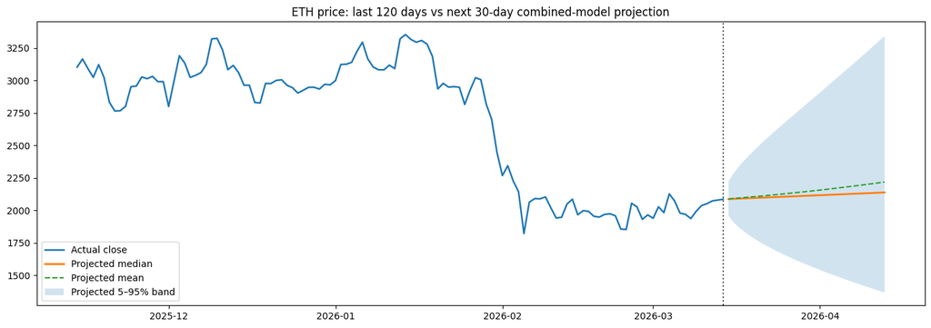

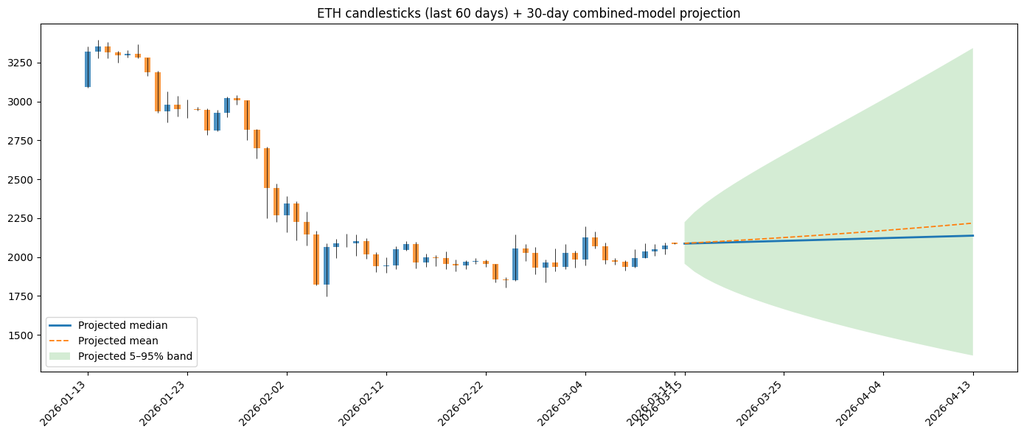

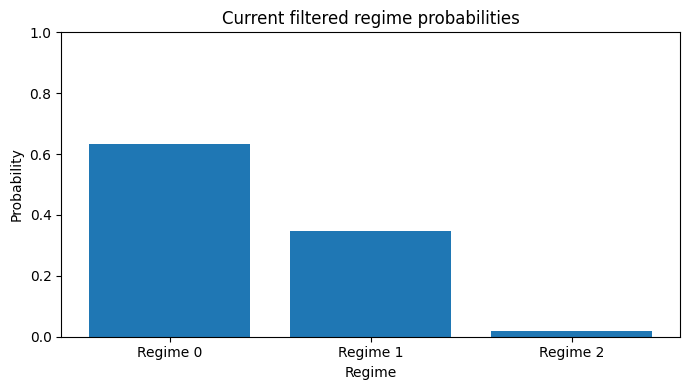

```
Current regime probabilities: [0.6341 0.3474 0.0185]
Current dominant regime: 0
Regime sigmas: [0.012766 0.036111 0.079968]
```

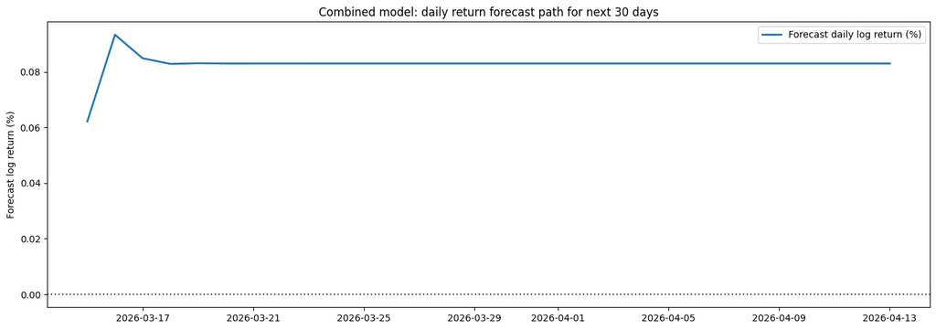

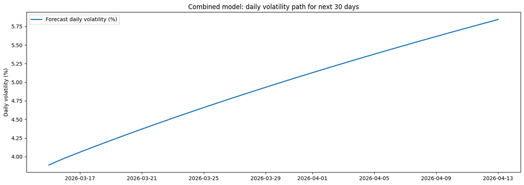

```
=== COMBINED FORECAST CHART SUMMARY ===
Raw GJR 30D forecast return:      2.514%
Adjusted combined 30D return:     2.263%
Projected median end price:       2137.90
Projected mean end price:         2218.42
Projected 5th percentile price:   1366.89
Projected 95th percentile price:  3343.81
Crisis probability:               1.85%
Combined daily volatility:        3.527%
Recommended position:             12.8%
Stance:                           BUY / HOLD SMALL
```

```python
# 1) Prepare plotting dataframe robustly

eth_plot = eth.copy()

if isinstance(eth_plot.columns, pd.MultiIndex):
    eth_plot.columns = [c[0] if isinstance(c, tuple) else c for c in eth_plot.columns]

needed = [c for c in ["Open", "High", "Low", "Close", "Volume"] if c in eth_plot.columns]
eth_plot = eth_plot[needed].copy()

last_close = float(eth_plot["Close"].dropna().iloc[-1])
forecast_start = eth_plot.index[-1] + pd.Timedelta(days=1)
future_idx = pd.date_range(forecast_start, periods=horizon, freq="D")

print("Last close:", round(last_close, 2))
print("Forecast start:", forecast_start.date(), "| Forecast horizon:", horizon, "days")


# 2) Build combined-model price projection fan
#    Base path = GJR mean forecast
#    Uncertainty = GJR vol forecast, scaled slightly by regime stress

mean_path_log = np.asarray(gjr_out["mean_path_log"], dtype=float)
vol_path = np.asarray(gjr_out["vol_path"], dtype=float)

# Add mild regime stress multiplier to widen fan when current regime risk is high
regime_stress_multiplier = 1.0 + crisis_prob
adj_vol_path = vol_path * regime_stress_multiplier

cum_mean_log = np.cumsum(mean_path_log)
cum_var_log = np.cumsum(adj_vol_path ** 2)
cum_sd_log = np.sqrt(cum_var_log)

z05 = -1.6448536269514722
z95 =  1.6448536269514722

proj_median = last_close * np.exp(cum_mean_log)
proj_mean = last_close * np.exp(cum_mean_log + 0.5 * cum_var_log)
proj_p05 = last_close * np.exp(cum_mean_log + z05 * cum_sd_log)
proj_p95 = last_close * np.exp(cum_mean_log + z95 * cum_sd_log)

print("Projected 30D median end price:", round(float(proj_median[-1]), 2))
print("Projected 30D mean end price:  ", round(float(proj_mean[-1]), 2))
print("Projected 30D 5th pct end price:", round(float(proj_p05[-1]), 2))
print("Projected 30D 95th pct end price:", round(float(proj_p95[-1]), 2))


# 3) Chart 1: recent close + projected fan

lookback = 120
recent_close = eth_plot["Close"].dropna().iloc[-lookback:]

plt.figure(figsize=(14, 5))
plt.plot(recent_close.index, recent_close.values, label="Actual close", linewidth=1.8)
plt.plot(future_idx, proj_median, label="Projected median", linewidth=2.0)
plt.plot(future_idx, proj_mean, label="Projected mean", linewidth=1.5, linestyle="--")
plt.fill_between(future_idx, proj_p05, proj_p95, alpha=0.20, label="Projected 5–95% band")
plt.axvline(recent_close.index[-1], color="black", linestyle=":", alpha=0.7)
plt.title("ETH price: last 120 days vs next 30-day combined-model projection")
plt.legend()
plt.tight_layout()
plt.show()


# 4) Chart 2: recent candlesticks + projected fan

def draw_simple_candles(ax, ohlc_df):
    up = ohlc_df["Close"] >= ohlc_df["Open"]
    down = ~up

    x = np.arange(len(ohlc_df))
    width = 0.6

    ax.vlines(x, ohlc_df["Low"], ohlc_df["High"], color="black", linewidth=0.7, alpha=0.8)

    ax.bar(
        x[up],
        ohlc_df["Close"][up] - ohlc_df["Open"][up],
        bottom=ohlc_df["Open"][up],
        width=width,
        alpha=0.8
    )
    ax.bar(
        x[down],
        ohlc_df["Close"][down] - ohlc_df["Open"][down],
        bottom=ohlc_df["Open"][down],
        width=width,
        alpha=0.8
    )

    return x

lookback_candles = 60
ohlc_recent = eth_plot[["Open", "High", "Low", "Close"]].dropna().iloc[-lookback_candles:].copy()

fig, ax = plt.subplots(figsize=(14, 6))
x_hist = draw_simple_candles(ax, ohlc_recent)

x_future = np.arange(len(ohlc_recent), len(ohlc_recent) + horizon)

ax.plot(x_future, proj_median, linewidth=2.0, label="Projected median")
ax.plot(x_future, proj_mean, linewidth=1.3, linestyle="--", label="Projected mean")
ax.fill_between(x_future, proj_p05, proj_p95, alpha=0.20, label="Projected 5–95% band")

hist_tick_idx = list(range(0, len(ohlc_recent), 10))
future_tick_idx = list(range(0, len(future_idx), 10))

tick_pos = [x_hist[i] for i in hist_tick_idx]
tick_lab = [ohlc_recent.index[i].strftime("%Y-%m-%d") for i in hist_tick_idx]

tick_pos += [x_future[i] for i in future_tick_idx]
tick_lab += [future_idx[i].strftime("%Y-%m-%d") for i in future_tick_idx]

if x_hist[-1] not in tick_pos:
    tick_pos.append(x_hist[-1])
    tick_lab.append(ohlc_recent.index[-1].strftime("%Y-%m-%d"))

if x_future[-1] not in tick_pos:
    tick_pos.append(x_future[-1])
    tick_lab.append(future_idx[-1].strftime("%Y-%m-%d"))

ax.set_xticks(tick_pos)
ax.set_xticklabels(tick_lab, rotation=45, ha="right")
ax.set_title("ETH candlesticks (last 60 days) + 30-day combined-model projection")
ax.legend()
plt.tight_layout()
plt.show()


# 5) Chart 3: current filtered regime probabilities

pi_live = pd.Series(pi0, index=[f"Regime {i}" for i in range(len(pi0))])

plt.figure(figsize=(7, 4))
plt.bar(pi_live.index, pi_live.values)
plt.title("Current filtered regime probabilities")
plt.xlabel("Regime")
plt.ylabel("Probability")
plt.ylim(0, 1)
plt.tight_layout()
plt.show()

print("Current regime probabilities:", np.round(pi_live.values, 4))
print("Current dominant regime:", int(np.argmax(pi0)))
print("Regime sigmas:", np.round(sigma, 6))


# 6) Chart 4: daily forecast return and volatility paths

fig, ax = plt.subplots(figsize=(14, 5))
ax.plot(future_idx, mean_path_log * 100, linewidth=2.0, label="Forecast daily log return (%)")
ax.axhline(0, color="black", linestyle=":", alpha=0.7)
ax.set_title("Combined model: daily return forecast path for next 30 days")
ax.set_ylabel("Forecast log return (%)")
ax.legend()
plt.tight_layout()
plt.show()

fig, ax = plt.subplots(figsize=(14, 5))
ax.plot(future_idx, adj_vol_path * 100, linewidth=2.0, label="Forecast daily volatility (%)")
ax.set_title("Combined model: daily volatility path for next 30 days")
ax.set_ylabel("Daily volatility (%)")
ax.legend()
plt.tight_layout()
plt.show()


# 7) Final chart summary

print("\n=== COMBINED FORECAST CHART SUMMARY ===")
print(f"Raw GJR 30D forecast return:      {raw_gjr_30d_return * 100:.3f}%")
print(f"Adjusted combined 30D return:     {adjusted_30d_return * 100:.3f}%")
print(f"Projected median end price:       {proj_median[-1]:.2f}")
print(f"Projected mean end price:         {proj_mean[-1]:.2f}")
print(f"Projected 5th percentile price:   {proj_p05[-1]:.2f}")
print(f"Projected 95th percentile price:  {proj_p95[-1]:.2f}")
print(f"Crisis probability:               {crisis_prob * 100:.2f}%")
print(f"Combined daily volatility:        {combined_vol * 100:.3f}%")
print(f"Recommended position:             {position * 100:.1f}%")
print(f"Stance:                           {stance}")
```

**Combined forecast model visualization**

The charts show the 30-day forecast generated by the combined AR(3)–GJR-GARCH + Markov regime model, comparing the recent ETH price path with the model’s projected price distribution for the next month.

The daily forecast paths show relatively stable expected returns over the next 30 days, while the volatility forecast gradually rises from roughly 4% to nearly 5.9% daily. Overall, the model indicates a slightly bullish environment with elevated volatility, resulting in the recommended allocation (about 12% of capital) and a “BUY / HOLD SMALL” stance.

## 13. Final Model Comparison Including the Combined Model

This section compares the simple benchmark models with the final combined model on the same 30-day forecast horizon and using a comparable strategy-output format.

```
=== RANKED BY EXPECTED 30D RETURN ===
```

|  | Model | Expected 30D Return % | Daily Volatility % | Approx 30D Volatility % | Forecast Sharpe Proxy | 30D Return / 30D Vol | Recommended Position % | ETH Allocation | Cash Allocation | Stance |
| --- | --- | --- | --- | --- | --- | --- | --- | --- | --- | --- |
| 0 | Combined AR(3)-GJR-GARCH + Markov | 2.263 | 3.527 | 19.316 | 0.404 | 0.117 | 12.8 | 1275.98 | 8724.02 | BUY / HOLD SMALL |
| 1 | AR(1) | 1.207 | 4.539 | 24.862 | 0.168 | 0.049 | 0.0 | 0.00 | 10000.00 | CASH / WAIT FOR CONFIRMATION |
| 2 | Holt-Winters | 0.359 | 4.539 | 24.862 | 0.050 | 0.014 | 0.0 | 0.00 | 10000.00 | CASH / WAIT FOR CONFIRMATION |
| 3 | ARIMA(2,0,2) | -3.796 | 4.539 | 24.862 | -0.543 | -0.153 | 0.0 | 0.00 | 10000.00 | CASH / BEARISH |

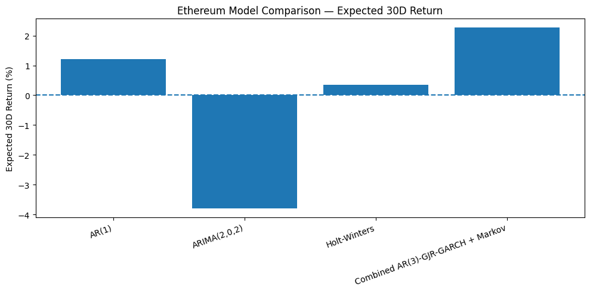

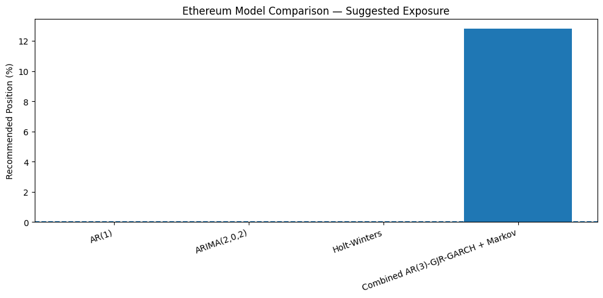

```
=== BEST MODEL SUMMARY ===
Best by expected 30D return: Combined AR(3)-GJR-GARCH + Markov (2.263%)
```

```python
# 1) Helper functions

def safe_pct(x):
    return float(x) * 100.0

def simple30_to_daily_log(ret_30d_simple, horizon=30):
    """
    Convert 30D simple return into equivalent average daily log return.
    """
    ret_30d_simple = float(ret_30d_simple)
    return np.log1p(ret_30d_simple) / horizon

def annualized_sharpe_proxy(ret_30d_simple, daily_vol, horizon=30, annual_days=365):
    """
    Forecast-based Sharpe-like ratio using implied daily log return / daily vol.
    This is a proxy, not a realized backtest Sharpe ratio.
    """
    daily_vol = float(daily_vol)
    if np.isnan(daily_vol) or daily_vol <= 0:
        return np.nan
    daily_log_mu = simple30_to_daily_log(ret_30d_simple, horizon=horizon)
    return (daily_log_mu / daily_vol) * np.sqrt(annual_days)

def horizon_vol_estimate(daily_vol, horizon=30):
    """
    Approximate 30D volatility from daily volatility.
    """
    daily_vol = float(daily_vol)
    if np.isnan(daily_vol) or daily_vol <= 0:
        return np.nan
    return daily_vol * np.sqrt(horizon)

def risk_adjusted_return_30d(ret_30d_simple, daily_vol, horizon=30):
    """
    30D return divided by approximate 30D volatility.
    """
    vol_30d = horizon_vol_estimate(daily_vol, horizon=horizon)
    if np.isnan(vol_30d) or vol_30d <= 0:
        return np.nan
    return float(ret_30d_simple) / vol_30d

def build_metrics_row(model, exp_30d_return, daily_vol, rec_position, eth_alloc, cash_alloc, stance, horizon=30):
    return {
        "Model": model,
        "Expected 30D Return %": round(safe_pct(exp_30d_return), 3),
        "Daily Volatility %": round(safe_pct(daily_vol), 3),
        "Approx 30D Volatility %": round(safe_pct(horizon_vol_estimate(daily_vol, horizon)), 3),
        "Forecast Sharpe Proxy": round(annualized_sharpe_proxy(exp_30d_return, daily_vol, horizon), 3),
        "30D Return / 30D Vol": round(risk_adjusted_return_30d(exp_30d_return, daily_vol, horizon), 3),
        "Recommended Position %": round(float(rec_position) * 100.0, 1),
        "ETH Allocation": round(float(eth_alloc), 2),
        "Cash Allocation": round(float(cash_alloc), 2),
        "Stance": stance
    }

# 2) Build ETH model metrics table

eth_metrics_rows = []

# AR(1)
eth_metrics_rows.append(
    build_metrics_row(
        model="AR(1)",
        exp_30d_return=ar1_30d_return,
        daily_vol=ar1_daily_vol,
        rec_position=ar1_output["Recommended Position %"] / 100.0,
        eth_alloc=ar1_output["ETH Allocation"],
        cash_alloc=ar1_output["Cash Allocation"],
        stance=ar1_output["Stance"],
        horizon=horizon
    )
)

# ARIMA(2,0,2)
eth_metrics_rows.append(
    build_metrics_row(
        model="ARIMA(2,0,2)",
        exp_30d_return=arima_30d_return,
        daily_vol=arima_daily_vol,
        rec_position=arima_output["Recommended Position %"] / 100.0,
        eth_alloc=arima_output["ETH Allocation"],
        cash_alloc=arima_output["Cash Allocation"],
        stance=arima_output["Stance"],
        horizon=horizon
    )
)

# Holt-Winters
eth_metrics_rows.append(
    build_metrics_row(
        model="Holt-Winters",
        exp_30d_return=hw_30d_return,
        daily_vol=hw_daily_vol,
        rec_position=hw_output["Recommended Position %"] / 100.0,
        eth_alloc=hw_output["ETH Allocation"],
        cash_alloc=hw_output["Cash Allocation"],
        stance=hw_output["Stance"],
        horizon=horizon
    )
)

# Combined model
eth_metrics_rows.append(
    build_metrics_row(
        model="Combined AR(3)-GJR-GARCH + Markov",
        exp_30d_return=adjusted_30d_return,
        daily_vol=combined_vol,
        rec_position=position,
        eth_alloc=eth_allocation,
        cash_alloc=cash_allocation,
        stance=stance,
        horizon=horizon
    )
)

eth_metrics_df = pd.DataFrame(eth_metrics_rows)

# 3) Ranked tables

print("\n=== RANKED BY EXPECTED 30D RETURN ===")
display(
    eth_metrics_df.sort_values("Expected 30D Return %", ascending=False).reset_index(drop=True)
)

# 5) Charts

# Return comparison
plt.figure(figsize=(10, 5))
plt.bar(eth_metrics_df["Model"], eth_metrics_df["Expected 30D Return %"])
plt.axhline(0, linestyle="--")
plt.ylabel("Expected 30D Return (%)")
plt.title("Ethereum Model Comparison — Expected 30D Return")
plt.xticks(rotation=20, ha="right")
plt.tight_layout()
plt.show()


# Position size comparison
plt.figure(figsize=(10, 5))
plt.bar(eth_metrics_df["Model"], eth_metrics_df["Recommended Position %"])
plt.axhline(0, linestyle="--")
plt.ylabel("Recommended Position (%)")
plt.title("Ethereum Model Comparison — Suggested Exposure")
plt.xticks(rotation=20, ha="right")
plt.tight_layout()
plt.show()

# 6) Best model summary

best_return_model = eth_metrics_df.sort_values("Expected 30D Return %", ascending=False).iloc[0]


print("\n=== BEST MODEL SUMMARY ===")
print(f"Best by expected 30D return: {best_return_model['Model']} ({best_return_model['Expected 30D Return %']:.3f}%)")
```

**Final Model + Baseline Models Comparison insights**

In contrast, the baseline models (AR(1), ARIMA, and Holt-Winters) generate much smaller or negative expected returns and therefore recommend no market exposure, resulting in a cash position. The combined model, however, identifies a modest positive opportunity and recommends a small allocation of about 12% to ETH, with the remainder held in cash.

Overall, this comparison reinforces that the combined framework provides the most actionable signal, balancing expected return with market risk, while the simpler models either produce weak signals or remain entirely defensive.